# Ficha de Información Metropolitana

Universidad Autónoma Metropolitnana

Lic. Martínez Rodriguez, Alvaro[^1]

Lic. Pérez Victorino, Leonardo[^2]

La ficha de información metropolitana es una herramienta valiosa para la planificación territorial en zonas metropolitanas (ZM). Proporciona información censal en diferentes formatos, como gráficos, tablas y mapas, tanto de los Censos de Población y Vivienda, 2020 (CPV2020) como de los Censos Económicos de 1999, 2004, 2009, 2014 y 2019. Ambos publicados por el Instituto Nacional de Estadística y Geografía (INEGI).

## Información general de la Zona Metropolitana de Cuernavaca

Según (Sedatu 2018), la zona metropolitana se define como un área urbana que consta de una ciudad principal y su zona conurbada. Las zonas metropolitanas se caracterizan por tener una alta densidad de población y estar interconectadas por vías de transporte y comunicación. La zona metropolitana de Cuernavaca, se localiza en Morelos. y esta compuesta por 8 municipios, que se muestran a continuación:

| Nombre | Clave |
| --- | --- |
| Cuernavaca | 17007 |
| Emiliano Zapata | 17008 |
| Huitzilac | 17009 |
| Jiutepec | 17011 |
| Temixco | 17018 |
| Tepoztlán | 17020 |
| Tlaltizapán de Zapata | 17024 |
| Xochitepec | 17028 |

Municipios de la zona metropolitana

Además, se presenta un mapa de la zona metropolitana:

[interactive chart not shown]

A continuación se presentan algunos datos generales sobre esta zona:

- Zona Metropolitana:Cuernavaca
- Número de municipios: 8
- Población total: 1,028,589
- Superficie de la ZM: 1,184.6 [m^2]
- Densidad poblacional: 868.301 [1/m^2] Hab/Km^2.
- Grado promedio de escolaridad: 9.8825

## Información sociodemográfica

La estructura de población de la zona metropolitana de Cuernavaca se presenta en la una piramide poblacional ya que permite obtener una visión general de la distribución de la población por género y edad:

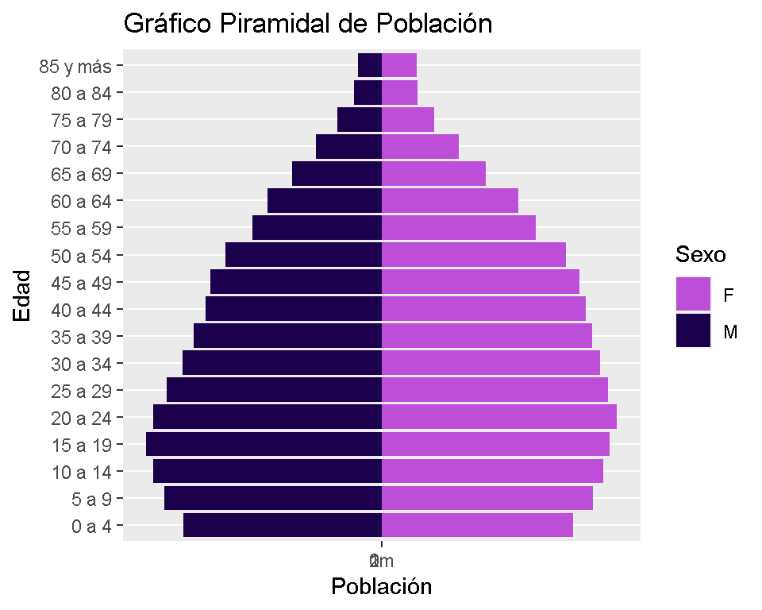

En el siguiente mapa se observa como se distribuye la población sobre la región:

[interactive chart not shown]

### Grupos de población

- Población total respecto al país: 1%. Este valor indica el peso poblacional de la zona metropolitana en relación con la población total de México.
- Población Masculina: 48%
- Población Femenina: 52%
- Relación M-F: 94.461. Este valor indica la proporción de hombres por cada mujer en la zona metropolitana.

### Socioeconómicos

La población en terminos de la poblacioón economicamente activa esta descrita por:

- Porcentaje de población de 12 años y más económicamente activa: 53%
- Porcentaje de población de 12 años y más no económicamente activa: 29% `

### Educación

La educación de la zona metropolitana esta caracterizada por los siguientes estadísticos:

- Porcentaje de población de 15 años y más sin escolaridad:3%
- Porcentaje de población de 15 años y más con al menos un grado aprobado en primaria: 71%
- Porcentaje de población de 15 años y más con educación básica completa: 19%
- Porcentaje de población de 15 años y más con secundaria o equivalente incompleta:2%
- Porcentaje de población de 18 años y más con al menos un grado aprobado en educación media superior: 38%

### Salud

La situación de la afiliación a algún servico de salud es la siguiente:

- Porcentaje de población afiliada a servicios de salud: 71%
- Población sin afiliación a servicios de salud:299769

### Indicadores de desarrollo

Finalmente se presentan tres indicadores de desarrollo; los índices son: índice de Desarrollo Humano (IDH), Índice de Marginación (IM) e Índice de Rezago Social (IRS).

IDH es un indicador elaborado por el Programa de Naciones Unidas para el Desarrollo (PNUD), este busca medir la calidad de vida, así como el progreso socioeconómico de cada entidad y municipio; El cálculo del Índice de Desarrollo Humano se realiza a partir de las tres variables: esperanza de vida, educación e ingreso per cápita.

- Muy Alto - IDH mayor de 1.
- Alto - IDH entre 0.80 a 1.
- Medio - IDH entre 0.50 y 0.80.
- Bajo - IDH entre 0 y 0.50
- Muy Bajo - IDH menores a 0.
- El promedio del IDH en 2020 para la zona metropolitana es de 0.766 según datos del PNUD.

El IM es un índice construido por el consejo Nacional de Población (CONAPO). Este índice considera 4 dimensiones estructurales para su construcción: vivienda, ingreso, educación y distribución de la población. El indice se puede ubicar en 5 estratos designados por la ténica de estratificación de Dalenius-Hodges..

Por último, el IRS es construido por el Consejo Nacional de Evaluación de la Política de Desarrollo Social, CONEVAL, este índice incorpora indicadores de educación, de acceso a servicios de salud, de servicios básicos y tiene como finalidad ordenar los municipios según sus carencias sociales. Este índice, al igual que el IM, se clasifica en cinco estratos.

## Datos económicos.

Con base en la información de los subsectores de los 21 sectores principales de la clasificación del SCIAN, extraída de los Censos Económicos del INEGI durante el periodo de 1998-2018, se ha llevado a cabo la agrupación de los datos de cada municipio que pertenece a una zona metropolitana en cinco grandes sectores: Primarios, Construcción, Manufactura, Comercio y Servicios. Esta clasificación se basa en la metodología proporcionada por el INEGI. Se utilizaron las siguientes variables:

- Unidades económicas (UE) [número de unidades]
- Activiso fijos totales (AF) [miles de pesos a precios corrientes]
- Formación bruta de capital fijo (FB) [miles de pesos a precios corrientes]
- Producción bruta total (PB) [miles de pesos a precios corrientes]
- Personal ocupado total (PO) [número de personas]
- Total de remuneraciones (RE) [miles de pesos a precios corrientes]
- Valor agregado censal bruto (VA) [miles de pesos a precios corrientes]

Posteriormente, se replica la metodología utilizada por García y Carranco (2008) para estimar los coeficientes de participación relativa (PR), de localización de la actividad económica (QL), Hirschman-Herfindahl (HH) e Inverso de Hirschman-Herfindahl (IHH).

$PR_ij$=$X_ij/X_in$

$QL_ij$=$(X_ij⁄X_j )/(X_in⁄X_n)$

$HH_ij$=$X_ij/X_in - X_j/X_n$

$IHH_ij$=$1/(X_ij/X_in - X_j/X_n)$

### Cifras brutas

#### 1999

##### UE

| Clave | Municipio | Primarios | Construcción | Manufactura | Comercio | Servicios |
| --- | --- | --- | --- | --- | --- | --- |
| 17007 | Cuernavaca | 6 | 74 | 1,183 | 7,903 | 6,398 |
| 17008 | Emiliano Zapata | 9 | 0 | 330 | 930 | 268 |
| 17009 | Huitzilac | 0 | 0 | 64 | 277 | 228 |
| 17011 | Jiutepec | 9 | 0 | 664 | 2,971 | 1,602 |
| 17018 | Temixco | 10 | 0 | 311 | 1,688 | 839 |
| 17020 | Tepoztlán | 0 | 0 | 69 | 369 | 165 |
| 17024 | Tlaltizapán de Zapata | 0 | 0 | 170 | 594 | 265 |
| 17028 | Xochitepec | 0 | 0 | 119 | 745 | 350 |

##### AF

| Clave | Municipio | Primarios | Construcción | Manufactura | Comercio | Servicios |
| --- | --- | --- | --- | --- | --- | --- |
| 17007 | Cuernavaca | 13,693 | 115,612 | 2,766,610 | 1,221,923 | 5,887,563 |
| 17008 | Emiliano Zapata | 8,193 | 1,715 | 1,147,535 | 41,777 | 125,185 |
| 17009 | Huitzilac | 0 | 0 | 7,514 | 7,622 | 38,821 |
| 17011 | Jiutepec | 6,404 | 6,552 | 8,259,369 | 369,658 | 409,643 |
| 17018 | Temixco | 5,839 | 76,183 | 33,252 | 72,671 | 248,704 |
| 17020 | Tepoztlán | 350 | 35 | 6,876 | 16,834 | 218,659 |
| 17024 | Tlaltizapán de Zapata | 2,421 | 560 | 12,601 | 23,209 | 40,059 |
| 17028 | Xochitepec | 352 | 4,825 | 13,960 | 42,788 | 33,781 |

##### FB

| Clave | Municipio | Primarios | Construcción | Manufactura | Comercio | Servicios |
| --- | --- | --- | --- | --- | --- | --- |
| 17007 | Cuernavaca | 21 | 13,694 | 309,552 | 51,542 | 738,958 |
| 17008 | Emiliano Zapata | 158 | 132 | 12,125 | 810 | 11,961 |
| 17009 | Huitzilac | 0 | 0 | 32 | 16 | 2,113 |
| 17011 | Jiutepec | 60 | 829 | 545,624 | 27,161 | 10,335 |
| 17018 | Temixco | 0 | 3,216 | 1,739 | 1,459 | 18,630 |
| 17020 | Tepoztlán | 0 | 1 | 85 | 261 | 6,796 |
| 17024 | Tlaltizapán de Zapata | -6 | 18 | 293 | 433 | 1,121 |
| 17028 | Xochitepec | 0 | 0 | 610 | 191 | 450 |

##### PB

| Clave | Municipio | Primarios | Construcción | Manufactura | Comercio | Servicios |
| --- | --- | --- | --- | --- | --- | --- |
| 17007 | Cuernavaca | 26,635 | 554,497 | 3,595,302 | 2,197,832 | 3,606,190 |
| 17008 | Emiliano Zapata | 30,001 | 3,744 | 583,825 | 50,505 | 337,450 |
| 17009 | Huitzilac | 0 | 0 | 29,084 | 9,078 | 38,894 |
| 17011 | Jiutepec | 8,943 | 19,138 | 16,149,453 | 738,316 | 504,458 |
| 17018 | Temixco | 11,800 | 80,991 | 92,562 | 98,155 | 112,300 |
| 17020 | Tepoztlán | 765 | 59 | 8,358 | 28,997 | 64,768 |
| 17024 | Tlaltizapán de Zapata | 2,217 | 1,915 | 25,433 | 16,318 | 19,424 |
| 17028 | Xochitepec | 1,558 | 831 | 48,589 | 48,053 | 139,387 |

##### PO

| Clave | Municipio | Primarios | Construcción | Manufactura | Comercio | Servicios |
| --- | --- | --- | --- | --- | --- | --- |
| 17007 | Cuernavaca | 96 | 3,646 | 11,242 | 21,896 | 33,288 |
| 17008 | Emiliano Zapata | 78 | 37 | 1,616 | 1,652 | 1,372 |
| 17009 | Huitzilac | 0 | 0 | 242 | 400 | 993 |
| 17011 | Jiutepec | 91 | 346 | 13,797 | 7,658 | 5,471 |
| 17018 | Temixco | 64 | 436 | 1,299 | 2,733 | 2,251 |
| 17020 | Tepoztlán | 0 | 2 | 171 | 642 | 1,022 |
| 17024 | Tlaltizapán de Zapata | 38 | 19 | 487 | 927 | 790 |
| 17028 | Xochitepec | 12 | 21 | 332 | 1,082 | 747 |

##### RE

| Clave | Municipio | Primarios | Construcción | Manufactura | Comercio | Servicios |
| --- | --- | --- | --- | --- | --- | --- |
| 17007 | Cuernavaca | 5,994 | 66,672 | 670,227 | 413,328 | 1,291,010 |
| 17008 | Emiliano Zapata | 3,277 | 627 | 53,214 | 4,789 | 48,430 |
| 17009 | Huitzilac | 0 | 0 | 2,079 | 764 | 3,742 |
| 17011 | Jiutepec | 2,637 | 2,840 | 1,051,789 | 166,007 | 126,717 |
| 17018 | Temixco | 1,392 | 9,174 | 11,087 | 10,667 | 35,679 |
| 17020 | Tepoztlán | 0 | 0 | 836 | 2,555 | 17,142 |
| 17024 | Tlaltizapán de Zapata | 64 | 229 | 2,784 | 1,302 | 6,525 |
| 17028 | Xochitepec | 115 | 522 | 3,475 | 6,829 | 2,893 |

##### VA

| Clave | Municipio | Primarios | Construcción | Manufactura | Comercio | Servicios |
| --- | --- | --- | --- | --- | --- | --- |
| 17007 | Cuernavaca | -9,319 | 107,056 | 1,160,266 | 1,489,664 | 1,199,146 |
| 17008 | Emiliano Zapata | 16,602 | 1,138 | 340,520 | 35,456 | 70,637 |
| 17009 | Huitzilac | 0 | 0 | 7,173 | 7,313 | 21,033 |
| 17011 | Jiutepec | -953 | 3,321 | 5,991,329 | 481,993 | 296,930 |
| 17018 | Temixco | 7,491 | 33,321 | 35,436 | 71,828 | 45,123 |
| 17020 | Tepoztlán | 688 | 7 | 2,938 | 22,932 | 29,411 |
| 17024 | Tlaltizapán de Zapata | 894 | 238 | 8,286 | 11,395 | 3,289 |
| 17028 | Xochitepec | 905 | 527 | 17,777 | 40,294 | 111,760 |

#### 2004

##### UE

| Clave | Municipio | Primarios | Construcción | Manufactura | Comercio | Servicios |
| --- | --- | --- | --- | --- | --- | --- |
| 17007 | Cuernavaca | 0 | 21 | 1,207 | 8,492 | 6,837 |
| 17008 | Emiliano Zapata | 0 | 0 | 328 | 1,213 | 268 |
| 17009 | Huitzilac | 0 | 0 | 109 | 314 | 271 |
| 17011 | Jiutepec | 0 | 0 | 643 | 3,382 | 1,837 |
| 17018 | Temixco | 0 | 0 | 371 | 2,193 | 933 |
| 17020 | Tepoztlán | 0 | 0 | 87 | 407 | 221 |
| 17024 | Tlaltizapán de Zapata | 0 | 0 | 211 | 768 | 405 |
| 17028 | Xochitepec | 0 | 0 | 182 | 941 | 485 |

##### AF

| Clave | Municipio | Primarios | Construcción | Manufactura | Comercio | Servicios |
| --- | --- | --- | --- | --- | --- | --- |
| 17007 | Cuernavaca | 413 | 164,929 | 1,759,543 | 2,275,481 | 7,682,668 |
| 17008 | Emiliano Zapata | 50,279 | 4,758 | 2,313,190 | 94,903 | 243,838 |
| 17009 | Huitzilac | 0 | 0 | 14,911 | 10,097 | 66,503 |
| 17011 | Jiutepec | 13,976 | 33,127 | 4,810,312 | 595,594 | 721,560 |
| 17018 | Temixco | 25,706 | 161 | 56,212 | 135,160 | 248,991 |
| 17020 | Tepoztlán | 0 | 97 | 4,615 | 25,732 | 108,707 |
| 17024 | Tlaltizapán de Zapata | 608 | 321 | 24,264 | 41,151 | 72,346 |
| 17028 | Xochitepec | 5,340 | 274 | 168,245 | 61,497 | 80,009 |

##### FB

| Clave | Municipio | Primarios | Construcción | Manufactura | Comercio | Servicios |
| --- | --- | --- | --- | --- | --- | --- |
| 17007 | Cuernavaca | 21 | 26,170 | 314,520 | 47,156 | 1,188,203 |
| 17008 | Emiliano Zapata | 31 | 0 | 16,297 | 2,703 | 40,143 |
| 17009 | Huitzilac | 0 | 0 | 1,212 | 1,596 | 2,316 |
| 17011 | Jiutepec | 2 | 1,295 | 271,996 | 38,072 | 38,128 |
| 17018 | Temixco | 1,220 | 0 | 1,284 | 6,171 | 7,990 |
| 17020 | Tepoztlán | 0 | 0 | 105 | 3,466 | 1,697 |
| 17024 | Tlaltizapán de Zapata | 0 | 0 | 1,053 | 1,317 | 2,838 |
| 17028 | Xochitepec | 0 | 130 | 6,536 | 1,621 | 2,516 |

##### PB

| Clave | Municipio | Primarios | Construcción | Manufactura | Comercio | Servicios |
| --- | --- | --- | --- | --- | --- | --- |
| 17007 | Cuernavaca | 1,812 | 1,022,364 | 4,575,939 | 3,865,331 | 7,025,761 |
| 17008 | Emiliano Zapata | 103,738 | 3,000 | 1,374,290 | 94,555 | 356,174 |
| 17009 | Huitzilac | 0 | 0 | 35,788 | 12,011 | 110,701 |
| 17011 | Jiutepec | 12,755 | 137,589 | 31,611,005 | 1,535,022 | 1,050,501 |
| 17018 | Temixco | 8,110 | 312 | 125,827 | 226,604 | 276,697 |
| 17020 | Tepoztlán | 336 | 210 | 13,980 | 48,129 | 170,896 |
| 17024 | Tlaltizapán de Zapata | 981 | 2,600 | 46,197 | 43,092 | 79,447 |
| 17028 | Xochitepec | 3,920 | 30,054 | 200,420 | 131,540 | 365,711 |

##### PO

| Clave | Municipio | Primarios | Construcción | Manufactura | Comercio | Servicios |
| --- | --- | --- | --- | --- | --- | --- |
| 17007 | Cuernavaca | 22 | 3,418 | 8,557 | 28,195 | 42,637 |
| 17008 | Emiliano Zapata | 275 | 23 | 2,388 | 2,285 | 1,838 |
| 17009 | Huitzilac | 0 | 0 | 314 | 454 | 789 |
| 17011 | Jiutepec | 57 | 265 | 14,762 | 10,067 | 11,153 |
| 17018 | Temixco | 40 | 6 | 1,392 | 4,087 | 3,235 |
| 17020 | Tepoztlán | 3 | 4 | 199 | 880 | 1,343 |
| 17024 | Tlaltizapán de Zapata | 12 | 28 | 671 | 1,277 | 1,125 |
| 17028 | Xochitepec | 24 | 313 | 1,028 | 1,791 | 1,716 |

##### RE

| Clave | Municipio | Primarios | Construcción | Manufactura | Comercio | Servicios |
| --- | --- | --- | --- | --- | --- | --- |
| 17007 | Cuernavaca | 222 | 90,355 | 677,037 | 751,810 | 1,972,150 |
| 17008 | Emiliano Zapata | 28,995 | 980 | 85,262 | 10,183 | 91,409 |
| 17009 | Huitzilac | 0 | 0 | 2,292 | 804 | 6,779 |
| 17011 | Jiutepec | 3,011 | 10,017 | 2,022,629 | 337,050 | 312,185 |
| 17018 | Temixco | 908 | 32 | 20,999 | 21,739 | 63,699 |
| 17020 | Tepoztlán | 117 | 62 | 1,358 | 5,838 | 22,323 |
| 17024 | Tlaltizapán de Zapata | 236 | 202 | 8,521 | 4,273 | 19,135 |
| 17028 | Xochitepec | 190 | 4,579 | 11,735 | 26,078 | 28,621 |

##### VA

| Clave | Municipio | Primarios | Construcción | Manufactura | Comercio | Servicios |
| --- | --- | --- | --- | --- | --- | --- |
| 17007 | Cuernavaca | 798 | 237,592 | 1,586,428 | 2,711,734 | 3,710,775 |
| 17008 | Emiliano Zapata | 91,773 | 2,296 | 609,985 | 72,156 | 249,617 |
| 17009 | Huitzilac | 0 | 0 | 9,350 | 9,868 | 54,927 |
| 17011 | Jiutepec | 5,069 | 41,146 | 13,888,503 | 1,087,758 | 547,199 |
| 17018 | Temixco | 5,531 | 117 | 54,614 | 183,171 | 169,072 |
| 17020 | Tepoztlán | 120 | 132 | 5,065 | 36,743 | 65,049 |
| 17024 | Tlaltizapán de Zapata | 364 | 922 | 20,004 | 33,488 | 44,151 |
| 17028 | Xochitepec | 2,888 | 7,724 | 66,613 | 103,464 | 293,707 |

#### 2009

##### UE

| Clave | Municipio | Primarios | Construcción | Manufactura | Comercio | Servicios |
| --- | --- | --- | --- | --- | --- | --- |
| 17007 | Cuernavaca | 0 | 109 | 1,675 | 10,100 | 8,987 |
| 17008 | Emiliano Zapata | 0 | 0 | 408 | 1,461 | 692 |
| 17009 | Huitzilac | 0 | 0 | 73 | 362 | 265 |
| 17011 | Jiutepec | 0 | 13 | 841 | 3,749 | 2,528 |
| 17018 | Temixco | 5 | 0 | 475 | 2,110 | 1,187 |
| 17020 | Tepoztlán | 0 | 0 | 149 | 512 | 390 |
| 17024 | Tlaltizapán de Zapata | 45 | 0 | 181 | 899 | 593 |
| 17028 | Xochitepec | 10 | 0 | 232 | 1,083 | 602 |

##### AF

| Clave | Municipio | Primarios | Construcción | Manufactura | Comercio | Servicios |
| --- | --- | --- | --- | --- | --- | --- |
| 17007 | Cuernavaca | 2,730 | 582,803 | 2,925,161 | 3,315,505 | 23,819,876 |
| 17008 | Emiliano Zapata | 49,572 | 0 | 3,556,370 | 112,990 | 170,115 |
| 17009 | Huitzilac | 0 | 0 | 12,453 | 41,408 | 58,996 |
| 17011 | Jiutepec | 1,019 | 21,473 | 6,773,765 | 847,620 | 754,861 |
| 17018 | Temixco | 11,998 | 268 | 59,586 | 205,962 | 701,763 |
| 17020 | Tepoztlán | 0 | 0 | 7,105 | 37,027 | 296,132 |
| 17024 | Tlaltizapán de Zapata | 19,268 | 1,029 | 25,040 | 78,683 | 123,127 |
| 17028 | Xochitepec | 34,899 | 1,162 | 260,394 | 74,122 | 633,770 |

##### FB

| Clave | Municipio | Primarios | Construcción | Manufactura | Comercio | Servicios |
| --- | --- | --- | --- | --- | --- | --- |
| 17007 | Cuernavaca | 60 | 46,020 | 232,102 | 199,440 | 971,666 |
| 17008 | Emiliano Zapata | 35 | 0 | 1,855 | 3,681 | 10,379 |
| 17009 | Huitzilac | 0 | 0 | 219 | 267 | 141 |
| 17011 | Jiutepec | 19 | 389 | 765,253 | 51,163 | 19,478 |
| 17018 | Temixco | 29 | 1 | 1,932 | 17,181 | 9,569 |
| 17020 | Tepoztlán | 0 | 0 | 235 | 648 | 13,148 |
| 17024 | Tlaltizapán de Zapata | 620 | 0 | 128 | 6,585 | 1,885 |
| 17028 | Xochitepec | 900 | 0 | 76,274 | 3,378 | 4,179 |

##### PB

| Clave | Municipio | Primarios | Construcción | Manufactura | Comercio | Servicios |
| --- | --- | --- | --- | --- | --- | --- |
| 17007 | Cuernavaca | 359 | 2,529,103 | 6,761,379 | 5,884,386 | 16,624,658 |
| 17008 | Emiliano Zapata | 59,944 | 0 | 2,794,966 | 192,846 | 311,836 |
| 17009 | Huitzilac | 0 | 0 | 37,046 | 26,658 | 725,069 |
| 17011 | Jiutepec | 23,926 | 177,931 | 31,178,069 | 2,010,202 | 1,357,632 |
| 17018 | Temixco | 27,954 | 1,953 | 166,457 | 398,456 | 546,935 |
| 17020 | Tepoztlán | 0 | 0 | 28,554 | 73,942 | 350,908 |
| 17024 | Tlaltizapán de Zapata | 3,594 | 2,975 | 49,281 | 66,676 | 138,130 |
| 17028 | Xochitepec | 5,249 | 3,359 | 555,558 | 237,598 | 1,299,648 |

##### PO

| Clave | Municipio | Primarios | Construcción | Manufactura | Comercio | Servicios |
| --- | --- | --- | --- | --- | --- | --- |
| 17007 | Cuernavaca | 12 | 4,133 | 9,758 | 35,499 | 58,718 |
| 17008 | Emiliano Zapata | 98 | 0 | 1,961 | 3,297 | 2,656 |
| 17009 | Huitzilac | 0 | 0 | 236 | 650 | 1,085 |
| 17011 | Jiutepec | 75 | 335 | 16,422 | 12,033 | 11,246 |
| 17018 | Temixco | 78 | 13 | 1,567 | 5,386 | 4,821 |
| 17020 | Tepoztlán | 0 | 0 | 394 | 1,364 | 1,859 |
| 17024 | Tlaltizapán de Zapata | 188 | 17 | 551 | 1,905 | 1,909 |
| 17028 | Xochitepec | 71 | 7 | 1,339 | 2,449 | 2,844 |

##### RE

| Clave | Municipio | Primarios | Construcción | Manufactura | Comercio | Servicios |
| --- | --- | --- | --- | --- | --- | --- |
| 17007 | Cuernavaca | 62 | 279,106 | 783,621 | 955,048 | 3,458,048 |
| 17008 | Emiliano Zapata | 10,238 | 0 | 45,014 | 28,908 | 51,867 |
| 17009 | Huitzilac | 0 | 0 | 3,521 | 3,212 | 9,823 |
| 17011 | Jiutepec | 2,514 | 11,451 | 1,916,784 | 391,532 | 331,444 |
| 17018 | Temixco | 1,104 | 130 | 23,653 | 40,433 | 106,493 |
| 17020 | Tepoztlán | 0 | 0 | 4,341 | 12,252 | 50,086 |
| 17024 | Tlaltizapán de Zapata | 467 | 524 | 7,173 | 8,378 | 15,828 |
| 17028 | Xochitepec | 1,626 | 223 | 57,209 | 29,860 | 94,467 |

##### VA

| Clave | Municipio | Primarios | Construcción | Manufactura | Comercio | Servicios |
| --- | --- | --- | --- | --- | --- | --- |
| 17007 | Cuernavaca | 229 | 1,054,734 | 2,291,625 | 3,276,018 | 8,280,553 |
| 17008 | Emiliano Zapata | 46,686 | 0 | 1,538,147 | 128,491 | 156,707 |
| 17009 | Huitzilac | 0 | 0 | 13,401 | 20,725 | 514,342 |
| 17011 | Jiutepec | 17,290 | 38,958 | 9,752,924 | 1,250,442 | 646,232 |
| 17018 | Temixco | 14,297 | 848 | 70,838 | 251,501 | 242,647 |
| 17020 | Tepoztlán | 0 | 0 | 10,870 | 52,993 | 162,499 |
| 17024 | Tlaltizapán de Zapata | 2,384 | 524 | 20,463 | 45,883 | 53,479 |
| 17028 | Xochitepec | 2,644 | 427 | 241,468 | 173,096 | 755,883 |

#### 2014

##### UE

| Clave | Municipio | Primarios | Construcción | Manufactura | Comercio | Servicios |
| --- | --- | --- | --- | --- | --- | --- |
| 17007 | Cuernavaca | 0 | 112 | 1,544 | 9,519 | 9,036 |
| 17008 | Emiliano Zapata | 10 | 0 | 459 | 1,773 | 1,045 |
| 17009 | Huitzilac | 0 | 0 | 84 | 435 | 105 |
| 17011 | Jiutepec | 0 | 26 | 934 | 4,111 | 3,242 |
| 17018 | Temixco | 8 | 0 | 488 | 2,494 | 1,512 |
| 17020 | Tepoztlán | 0 | 0 | 182 | 634 | 572 |
| 17024 | Tlaltizapán de Zapata | 40 | 0 | 166 | 859 | 624 |
| 17028 | Xochitepec | 10 | 0 | 272 | 1,319 | 881 |

##### AF

| Clave | Municipio | Primarios | Construcción | Manufactura | Comercio | Servicios |
| --- | --- | --- | --- | --- | --- | --- |
| 17007 | Cuernavaca | 0 | 438,053 | 4,334,703 | 4,658,314 | 7,280,394 |
| 17008 | Emiliano Zapata | 44,693 | 0 | 2,049,083 | 227,287 | 300,177 |
| 17009 | Huitzilac | 0 | 0 | 25,843 | 108,148 | 27,004 |
| 17011 | Jiutepec | 0 | 39,595 | 10,699,161 | 921,895 | 940,859 |
| 17018 | Temixco | 37,765 | 0 | 65,602 | 503,415 | 669,592 |
| 17020 | Tepoztlán | 0 | 0 | 14,622 | 39,695 | 353,111 |
| 17024 | Tlaltizapán de Zapata | 25,816 | 0 | 30,439 | 52,125 | 118,838 |
| 17028 | Xochitepec | 7,100 | 0 | 226,532 | 246,456 | 340,566 |

##### FB

| Clave | Municipio | Primarios | Construcción | Manufactura | Comercio | Servicios |
| --- | --- | --- | --- | --- | --- | --- |
| 17007 | Cuernavaca | 0 | 24,635 | 347,503 | 254,651 | 186,557 |
| 17008 | Emiliano Zapata | 0 | 0 | 1,667 | 19,892 | 7,720 |
| 17009 | Huitzilac | 0 | 0 | 243 | 3,091 | 576 |
| 17011 | Jiutepec | 0 | 157 | 2,798,425 | 50,356 | 40,568 |
| 17018 | Temixco | 0 | 0 | 2,093 | 90,998 | 13,196 |
| 17020 | Tepoztlán | 0 | 0 | 222 | 1,089 | 2,618 |
| 17024 | Tlaltizapán de Zapata | 3 | 0 | 603 | 2,217 | 3,888 |
| 17028 | Xochitepec | 0 | 0 | 8,211 | 30,623 | 45,589 |

##### PB

| Clave | Municipio | Primarios | Construcción | Manufactura | Comercio | Servicios |
| --- | --- | --- | --- | --- | --- | --- |
| 17007 | Cuernavaca | 0 | 2,028,353 | 9,076,971 | 7,909,866 | 12,249,336 |
| 17008 | Emiliano Zapata | 96,970 | 0 | 2,637,702 | 405,465 | 322,608 |
| 17009 | Huitzilac | 0 | 0 | 72,643 | 38,487 | 1,335,120 |
| 17011 | Jiutepec | 0 | 184,269 | 60,588,255 | 2,066,136 | 1,511,334 |
| 17018 | Temixco | 11,570 | 0 | 160,912 | 887,091 | 1,758,051 |
| 17020 | Tepoztlán | 0 | 0 | 32,613 | 60,770 | 171,453 |
| 17024 | Tlaltizapán de Zapata | 3,475 | 0 | 67,584 | 63,213 | 182,786 |
| 17028 | Xochitepec | 2,240 | 0 | 454,632 | 377,169 | 496,088 |

##### PO

| Clave | Municipio | Primarios | Construcción | Manufactura | Comercio | Servicios |
| --- | --- | --- | --- | --- | --- | --- |
| 17007 | Cuernavaca | 0 | 3,558 | 9,608 | 31,463 | 53,216 |
| 17008 | Emiliano Zapata | 129 | 0 | 1,986 | 3,876 | 2,839 |
| 17009 | Huitzilac | 0 | 0 | 250 | 879 | 239 |
| 17011 | Jiutepec | 0 | 613 | 18,063 | 10,898 | 10,598 |
| 17018 | Temixco | 184 | 0 | 1,234 | 5,516 | 4,776 |
| 17020 | Tepoztlán | 0 | 0 | 382 | 1,082 | 1,684 |
| 17024 | Tlaltizapán de Zapata | 123 | 0 | 473 | 1,389 | 1,711 |
| 17028 | Xochitepec | 29 | 0 | 962 | 2,856 | 2,483 |

##### RE

| Clave | Municipio | Primarios | Construcción | Manufactura | Comercio | Servicios |
| --- | --- | --- | --- | --- | --- | --- |
| 17007 | Cuernavaca | 0 | 192,025 | 1,268,010 | 1,164,688 | 2,732,419 |
| 17008 | Emiliano Zapata | 10,226 | 0 | 80,176 | 51,825 | 53,851 |
| 17009 | Huitzilac | 0 | 0 | 5,586 | 9,495 | 893 |
| 17011 | Jiutepec | 0 | 41,197 | 2,957,318 | 329,664 | 275,381 |
| 17018 | Temixco | 1,832 | 0 | 20,529 | 111,314 | 83,052 |
| 17020 | Tepoztlán | 0 | 0 | 5,521 | 10,168 | 37,824 |
| 17024 | Tlaltizapán de Zapata | 256 | 0 | 11,111 | 4,144 | 41,178 |
| 17028 | Xochitepec | 234 | 0 | 49,738 | 41,045 | 118,476 |

##### VA

| Clave | Municipio | Primarios | Construcción | Manufactura | Comercio | Servicios |
| --- | --- | --- | --- | --- | --- | --- |
| 17007 | Cuernavaca | 0 | 759,446 | 3,114,241 | 5,215,470 | 6,214,441 |
| 17008 | Emiliano Zapata | 69,940 | 0 | 662,855 | 281,268 | 177,689 |
| 17009 | Huitzilac | 0 | 0 | 30,047 | 32,415 | 1,078,240 |
| 17011 | Jiutepec | 0 | 78,437 | 10,751,717 | 1,299,529 | 626,162 |
| 17018 | Temixco | -199,889 | 0 | 63,192 | 677,954 | 1,120,535 |
| 17020 | Tepoztlán | 0 | 0 | 15,778 | 44,753 | 77,876 |
| 17024 | Tlaltizapán de Zapata | 1,946 | 0 | 28,292 | 47,516 | 92,144 |
| 17028 | Xochitepec | 1,729 | 0 | 136,520 | 236,692 | 256,835 |

#### 2019

##### UE

| Clave | Municipio | Primarios | Construcción | Manufactura | Comercio | Servicios |
| --- | --- | --- | --- | --- | --- | --- |
| 17007 | Cuernavaca | 3 | 116 | 1,599 | 10,342 | 10,776 |
| 17008 | Emiliano Zapata | 6 | 6 | 406 | 1,877 | 1,214 |
| 17009 | Huitzilac | 1 | 1 | 132 | 541 | 409 |
| 17011 | Jiutepec | 9 | 27 | 896 | 4,394 | 3,588 |
| 17018 | Temixco | 7 | 5 | 565 | 2,713 | 1,945 |
| 17020 | Tepoztlán | 1 | 1 | 229 | 741 | 848 |
| 17024 | Tlaltizapán de Zapata | 51 | 4 | 177 | 906 | 627 |
| 17028 | Xochitepec | 12 | 1 | 298 | 1,389 | 1,133 |

##### AF

| Clave | Municipio | Primarios | Construcción | Manufactura | Comercio | Servicios |
| --- | --- | --- | --- | --- | --- | --- |
| 17007 | Cuernavaca | 0 | 1,114,308 | 5,866,621 | 6,866,123 | 7,855,995 |
| 17008 | Emiliano Zapata | 0 | 1,757 | 1,996,235 | 618,317 | 424,593 |
| 17009 | Huitzilac | 0 | 0 | 23,600 | 157,912 | 20,873 |
| 17011 | Jiutepec | 10,438 | 23,027 | 10,536,838 | 3,894,545 | 1,029,427 |
| 17018 | Temixco | 9,561 | 0 | 113,878 | 613,942 | 495,400 |
| 17020 | Tepoztlán | 0 | 0 | 30,449 | 143,537 | 685,545 |
| 17024 | Tlaltizapán de Zapata | 56,747 | 0 | 20,156 | 89,197 | 131,117 |
| 17028 | Xochitepec | 25,244 | 0 | 366,978 | 554,044 | 863,060 |

##### FB

| Clave | Municipio | Primarios | Construcción | Manufactura | Comercio | Servicios |
| --- | --- | --- | --- | --- | --- | --- |
| 17007 | Cuernavaca | 0 | 14,788 | 190,711 | 831,997 | 304,713 |
| 17008 | Emiliano Zapata | 0 | -238 | 11,770 | 44,530 | 22,355 |
| 17009 | Huitzilac | 0 | 0 | 1,505 | 921 | 625 |
| 17011 | Jiutepec | 2 | 1,095 | 680,704 | 236,713 | 28,004 |
| 17018 | Temixco | 43 | 0 | 4,248 | 44,519 | 12,699 |
| 17020 | Tepoztlán | 0 | 0 | 502 | 932 | 7,558 |
| 17024 | Tlaltizapán de Zapata | 155 | 0 | 1,649 | 5,866 | 5,578 |
| 17028 | Xochitepec | 1,180 | 0 | 20,109 | 12,228 | 30,501 |

##### PB

| Clave | Municipio | Primarios | Construcción | Manufactura | Comercio | Servicios |
| --- | --- | --- | --- | --- | --- | --- |
| 17007 | Cuernavaca | 0 | 3,153,303 | 14,123,210 | 14,813,733 | 18,028,774 |
| 17008 | Emiliano Zapata | 0 | 27,323 | 4,643,378 | 1,402,797 | 1,210,273 |
| 17009 | Huitzilac | 0 | 0 | 81,256 | 306,681 | 21,474 |
| 17011 | Jiutepec | 1,381 | 84,565 | 86,460,200 | 4,318,658 | 3,129,070 |
| 17018 | Temixco | 10,220 | 0 | 397,186 | 1,519,562 | 786,198 |
| 17020 | Tepoztlán | 0 | 0 | 59,149 | 168,717 | 459,779 |
| 17024 | Tlaltizapán de Zapata | 7,475 | 0 | 62,392 | 162,622 | 186,740 |
| 17028 | Xochitepec | 3,193 | 0 | 871,691 | 484,449 | 852,582 |

##### PO

| Clave | Municipio | Primarios | Construcción | Manufactura | Comercio | Servicios |
| --- | --- | --- | --- | --- | --- | --- |
| 17007 | Cuernavaca | 0 | 5,777 | 10,296 | 37,507 | 61,513 |
| 17008 | Emiliano Zapata | 0 | 169 | 1,676 | 4,963 | 4,765 |
| 17009 | Huitzilac | 0 | 0 | 432 | 1,080 | 387 |
| 17011 | Jiutepec | 32 | 109 | 20,069 | 11,229 | 14,176 |
| 17018 | Temixco | 127 | 0 | 2,043 | 6,072 | 5,282 |
| 17020 | Tepoztlán | 0 | 0 | 488 | 1,540 | 2,891 |
| 17024 | Tlaltizapán de Zapata | 211 | 0 | 355 | 1,444 | 1,368 |
| 17028 | Xochitepec | 35 | 0 | 1,133 | 2,795 | 3,588 |

##### RE

| Clave | Municipio | Primarios | Construcción | Manufactura | Comercio | Servicios |
| --- | --- | --- | --- | --- | --- | --- |
| 17007 | Cuernavaca | 0 | 289,981 | 1,354,996 | 1,575,532 | 3,481,883 |
| 17008 | Emiliano Zapata | 0 | 7,192 | 30,738 | 145,964 | 259,699 |
| 17009 | Huitzilac | 0 | 0 | 14,952 | 14,746 | 3,672 |
| 17011 | Jiutepec | 318 | 6,378 | 4,065,084 | 481,957 | 647,153 |
| 17018 | Temixco | 2,818 | 0 | 79,848 | 132,676 | 170,802 |
| 17020 | Tepoztlán | 0 | 0 | 11,147 | 36,726 | 82,087 |
| 17024 | Tlaltizapán de Zapata | 1,436 | 0 | 7,758 | 18,562 | 23,465 |
| 17028 | Xochitepec | 750 | 0 | 76,905 | 53,551 | 231,568 |

##### VA

| Clave | Municipio | Primarios | Construcción | Manufactura | Comercio | Servicios |
| --- | --- | --- | --- | --- | --- | --- |
| 17007 | Cuernavaca | 0 | 1,326,820 | 5,905,376 | 9,856,002 | 9,529,783 |
| 17008 | Emiliano Zapata | 0 | 12,712 | 2,271,271 | 1,131,328 | 675,368 |
| 17009 | Huitzilac | 0 | 0 | 47,914 | 271,448 | 11,011 |
| 17011 | Jiutepec | 497 | 40,098 | 25,114,895 | 3,067,850 | 1,643,111 |
| 17018 | Temixco | 6,766 | 0 | 157,313 | 1,203,990 | 426,326 |
| 17020 | Tepoztlán | 0 | 0 | 27,084 | 125,427 | 220,800 |
| 17024 | Tlaltizapán de Zapata | 2,088 | 0 | 26,336 | 127,088 | 75,941 |
| 17028 | Xochitepec | 1,194 | 0 | 394,642 | 359,348 | 527,326 |

### Coeficientes de localización (QL)

#### 1999

##### UE

| Clave | Municipio | Primarios | Construcción | Manufactura | Comercio | Servicios |
| --- | --- | --- | --- | --- | --- | --- |
| 17007 | Cuernavaca | 0.1451 | 0.7995 | 0.6850 | 0.9624 | 1.1651 |
| 17008 | Emiliano Zapata | 2.2047 | 0.0000 | 1.9351 | 1.1468 | 0.4942 |
| 17009 | Huitzilac | 0.0000 | 0.0000 | 1.0137 | 0.9227 | 1.1357 |
| 17011 | Jiutepec | 0.6459 | 0.0000 | 1.1408 | 1.0734 | 0.8655 |
| 17018 | Temixco | 1.3220 | 0.0000 | 0.9842 | 1.1233 | 0.8350 |
| 17020 | Tepoztlán | 0.0000 | 0.0000 | 1.0313 | 1.1598 | 0.7756 |
| 17024 | Tlaltizapán de Zapata | 0.0000 | 0.0000 | 1.4890 | 1.0941 | 0.7299 |
| 17028 | Xochitepec | 0.0000 | 0.0000 | 0.8835 | 1.1631 | 0.8171 |

##### AF

| Clave | Municipio | Primarios | Construcción | Manufactura | Comercio | Servicios |
| --- | --- | --- | --- | --- | --- | --- |
| 17007 | Cuernavaca | 0.0562 | 0.7589 | 0.8127 | 1.6080 | 1.0812 |
| 17008 | Emiliano Zapata | 0.2542 | 0.0850 | 2.5465 | 0.4153 | 0.1737 |
| 17009 | Huitzilac | 0.0000 | 0.0000 | 0.4093 | 1.8599 | 1.3220 |
| 17011 | Jiutepec | 0.0291 | 0.0475 | 2.6818 | 0.5377 | 0.0832 |
| 17018 | Temixco | 0.5494 | 11.4591 | 0.2238 | 2.1913 | 1.0465 |
| 17020 | Tepoztlán | 0.0592 | 0.0095 | 0.0832 | 0.9131 | 1.6550 |
| 17024 | Tlaltizapán de Zapata | 1.2616 | 0.4665 | 0.4697 | 3.8755 | 0.9335 |
| 17028 | Xochitepec | 0.1511 | 3.3112 | 0.4287 | 5.8865 | 0.6485 |

##### FB

[output not shown]

##### PB

| Clave | Municipio | Primarios | Construcción | Manufactura | Comercio | Servicios |
| --- | --- | --- | --- | --- | --- | --- |
| 17007 | Cuernavaca | 0.2674 | 1.5397 | 0.7280 | 1.5759 | 1.1313 |
| 17008 | Emiliano Zapata | 2.9899 | 0.1032 | 1.1734 | 0.3594 | 1.0508 |
| 17009 | Huitzilac | 0.0000 | 0.0000 | 0.7628 | 0.8431 | 1.5804 |
| 17011 | Jiutepec | 0.0514 | 0.0304 | 1.8735 | 0.3033 | 0.0907 |
| 17018 | Temixco | 2.9875 | 5.6707 | 0.4726 | 1.7747 | 0.8883 |
| 17020 | Tepoztlán | 0.7447 | 0.0159 | 0.1641 | 2.0157 | 1.9699 |
| 17024 | Tlaltizapán de Zapata | 3.4018 | 0.8126 | 0.7870 | 1.7881 | 0.9312 |
| 17028 | Xochitepec | 0.6548 | 0.0966 | 0.4119 | 1.4424 | 1.8305 |

##### PO

| Clave | Municipio | Primarios | Construcción | Manufactura | Comercio | Servicios |
| --- | --- | --- | --- | --- | --- | --- |
| 17007 | Cuernavaca | 0.1542 | 0.9676 | 0.5190 | 1.2027 | 1.2847 |
| 17008 | Emiliano Zapata | 1.8493 | 0.1449 | 1.1010 | 1.3390 | 0.7814 |
| 17009 | Huitzilac | 0.0000 | 0.0000 | 0.4795 | 0.9429 | 1.6447 |
| 17011 | Jiutepec | 0.3749 | 0.2355 | 1.6334 | 1.0786 | 0.5414 |
| 17018 | Temixco | 1.0637 | 1.1970 | 0.6204 | 1.5529 | 0.8987 |
| 17020 | Tepoztlán | 0.0000 | 0.0203 | 0.3016 | 1.3469 | 1.5066 |
| 17024 | Tlaltizapán de Zapata | 1.8947 | 0.1565 | 0.6978 | 1.5801 | 0.9462 |
| 17028 | Xochitepec | 0.6166 | 0.1782 | 0.4902 | 1.9007 | 0.9220 |

##### RE

| Clave | Municipio | Primarios | Construcción | Manufactura | Comercio | Servicios |
| --- | --- | --- | --- | --- | --- | --- |
| 17007 | Cuernavaca | 0.2160 | 1.0601 | 0.7407 | 1.1894 | 1.1691 |
| 17008 | Emiliano Zapata | 2.6190 | 0.2211 | 1.3044 | 0.3057 | 0.9728 |
| 17009 | Huitzilac | 0.0000 | 0.0000 | 0.8539 | 0.8170 | 1.2594 |
| 17011 | Jiutepec | 0.1722 | 0.0819 | 2.1072 | 0.8660 | 0.2080 |
| 17018 | Temixco | 1.8051 | 5.2498 | 0.4410 | 1.1047 | 1.1629 |
| 17020 | Tepoztlán | 0.0000 | 0.0000 | 0.1101 | 0.8763 | 1.8502 |
| 17024 | Tlaltizapán de Zapata | 0.5176 | 0.8172 | 0.6905 | 0.8409 | 1.3262 |
| 17028 | Xochitepec | 0.7330 | 1.4683 | 0.6794 | 3.4763 | 0.4635 |

##### VA

| Clave | Municipio | Primarios | Construcción | Manufactura | Comercio | Servicios |
| --- | --- | --- | --- | --- | --- | --- |
| 17007 | Cuernavaca | -0.2008 | 1.2201 | 0.7979 | 1.6945 | 0.8106 |
| 17008 | Emiliano Zapata | 3.0409 | 0.1102 | 1.9903 | 0.3428 | 0.4058 |
| 17009 | Huitzilac | 0.0000 | 0.0000 | 0.5481 | 0.9243 | 1.5799 |
| 17011 | Jiutepec | -0.0120 | 0.0221 | 2.4010 | 0.3195 | 0.1170 |
| 17018 | Temixco | 3.2978 | 7.7578 | 0.4978 | 1.6691 | 0.6231 |
| 17020 | Tepoztlán | 1.0454 | 0.0056 | 0.1425 | 1.8392 | 1.4018 |
| 17024 | Tlaltizapán de Zapata | 3.1548 | 0.4442 | 0.9331 | 2.1226 | 0.3641 |
| 17028 | Xochitepec | 0.4494 | 0.1384 | 0.2817 | 1.0563 | 1.7410 |

#### 2004

##### UE

| Clave | Municipio | Primarios | Construcción | Manufactura | Comercio | Servicios |
| --- | --- | --- | --- | --- | --- | --- |
| 17007 | Cuernavaca | 0.0000 | 0.2563 | 0.7458 | 0.9499 | 1.1613 |
| 17008 | Emiliano Zapata | 0.0000 | 0.0000 | 1.8550 | 1.2419 | 0.4166 |
| 17009 | Huitzilac | 0.0000 | 0.0000 | 1.6068 | 0.8380 | 1.0982 |
| 17011 | Jiutepec | 0.0000 | 0.0000 | 1.1222 | 1.0685 | 0.8813 |
| 17018 | Temixco | 0.0000 | 0.0000 | 1.0854 | 1.1615 | 0.7503 |
| 17020 | Tepoztlán | 0.0000 | 0.0000 | 1.2449 | 1.0543 | 0.8693 |
| 17024 | Tlaltizapán de Zapata | 0.0000 | 0.0000 | 1.5597 | 1.0277 | 0.8230 |
| 17028 | Xochitepec | 0.0000 | 0.0000 | 1.1579 | 1.0838 | 0.8483 |

##### AF

| Clave | Municipio | Primarios | Construcción | Manufactura | Comercio | Servicios |
| --- | --- | --- | --- | --- | --- | --- |
| 17007 | Cuernavaca | 0.0021 | 1.2633 | 0.4042 | 2.1292 | 1.2527 |
| 17008 | Emiliano Zapata | 1.1168 | 0.1600 | 2.3325 | 0.3898 | 0.1745 |
| 17009 | Huitzilac | 0.0000 | 0.0000 | 0.4448 | 1.2268 | 1.4081 |
| 17011 | Jiutepec | 0.1361 | 0.4883 | 2.1265 | 1.0725 | 0.2264 |
| 17018 | Temixco | 3.3153 | 0.0314 | 0.3291 | 3.2234 | 1.0348 |
| 17020 | Tepoztlán | 0.0000 | 0.0634 | 0.0905 | 2.0561 | 1.5137 |
| 17024 | Tlaltizapán de Zapata | 0.2636 | 0.2107 | 0.4775 | 3.2991 | 1.0107 |
| 17028 | Xochitepec | 1.0181 | 0.0791 | 1.4562 | 2.1682 | 0.4916 |

##### FB

[output not shown]

##### PB

| Clave | Municipio | Primarios | Construcción | Manufactura | Comercio | Servicios |
| --- | --- | --- | --- | --- | --- | --- |
| 17007 | Cuernavaca | 0.0108 | 1.9586 | 0.6007 | 1.7064 | 1.1871 |
| 17008 | Emiliano Zapata | 5.2552 | 0.0491 | 1.5402 | 0.3564 | 0.5138 |
| 17009 | Huitzilac | 0.0000 | 0.0000 | 0.4888 | 0.5517 | 1.9461 |
| 17011 | Jiutepec | 0.0363 | 0.1266 | 1.9926 | 0.3254 | 0.0852 |
| 17018 | Temixco | 1.2448 | 0.0155 | 0.4273 | 2.5876 | 1.2093 |
| 17020 | Tepoztlán | 0.1408 | 0.0284 | 0.1296 | 1.5003 | 2.0389 |
| 17024 | Tlaltizapán de Zapata | 0.5571 | 0.4767 | 0.5804 | 1.8206 | 1.2847 |
| 17028 | Xochitepec | 0.5243 | 1.2978 | 0.5931 | 1.3089 | 1.3928 |

##### PO

| Clave | Municipio | Primarios | Construcción | Manufactura | Comercio | Servicios |
| --- | --- | --- | --- | --- | --- | --- |
| 17007 | Cuernavaca | 0.0321 | 0.8921 | 0.3921 | 1.1643 | 1.3211 |
| 17008 | Emiliano Zapata | 4.8862 | 0.0730 | 1.3311 | 1.1478 | 0.6928 |
| 17009 | Huitzilac | 0.0000 | 0.0000 | 0.7654 | 0.9973 | 1.3006 |
| 17011 | Jiutepec | 0.1900 | 0.1578 | 1.5433 | 0.9485 | 0.7885 |
| 17018 | Temixco | 0.5524 | 0.0148 | 0.6031 | 1.5958 | 0.9478 |
| 17020 | Tepoztlán | 0.1494 | 0.0356 | 0.3109 | 1.2392 | 1.4190 |
| 17024 | Tlaltizapán de Zapata | 0.4664 | 0.1945 | 0.8181 | 1.4031 | 0.9275 |
| 17028 | Xochitepec | 0.5960 | 1.3889 | 0.8008 | 1.2574 | 0.9040 |

##### RE

| Clave | Municipio | Primarios | Construcción | Manufactura | Comercio | Servicios |
| --- | --- | --- | --- | --- | --- | --- |
| 17007 | Cuernavaca | 0.0067 | 0.9910 | 0.5529 | 1.3773 | 1.2351 |
| 17008 | Emiliano Zapata | 14.0466 | 0.1731 | 1.1212 | 0.3004 | 0.9218 |
| 17009 | Huitzilac | 0.0000 | 0.0000 | 0.6618 | 0.5208 | 1.5011 |
| 17011 | Jiutepec | 0.1178 | 0.1429 | 2.1480 | 0.8030 | 0.2543 |
| 17018 | Temixco | 0.8883 | 0.0114 | 0.5576 | 1.2950 | 1.2972 |
| 17020 | Tepoztlán | 0.4138 | 0.0799 | 0.1304 | 1.2574 | 1.6436 |
| 17024 | Tlaltizapán de Zapata | 0.7659 | 0.2390 | 0.7506 | 0.8444 | 1.2927 |
| 17028 | Xochitepec | 0.2803 | 2.4628 | 0.4699 | 2.3427 | 0.8790 |

##### VA

| Clave | Municipio | Primarios | Construcción | Manufactura | Comercio | Servicios |
| --- | --- | --- | --- | --- | --- | --- |
| 17007 | Cuernavaca | 0.0060 | 1.2892 | 0.5918 | 1.6690 | 1.0237 |
| 17008 | Emiliano Zapata | 5.5525 | 0.1002 | 1.8295 | 0.3570 | 0.5536 |
| 17009 | Huitzilac | 0.0000 | 0.0000 | 0.3880 | 0.6756 | 1.6855 |
| 17011 | Jiutepec | 0.0202 | 0.1183 | 2.7444 | 0.3546 | 0.0800 |
| 17018 | Temixco | 0.8322 | 0.0127 | 0.4073 | 2.2540 | 0.9326 |
| 17020 | Tepoztlán | 0.0695 | 0.0551 | 0.1455 | 1.7413 | 1.3818 |
| 17024 | Tlaltizapán de Zapata | 0.2284 | 0.4171 | 0.6221 | 1.7183 | 1.0154 |
| 17028 | Xochitepec | 0.3778 | 0.7286 | 0.4320 | 1.1071 | 1.4087 |

#### 2009

##### UE

| Clave | Municipio | Primarios | Construcción | Manufactura | Comercio | Servicios |
| --- | --- | --- | --- | --- | --- | --- |
| 17007 | Cuernavaca | 0.0000 | 0.8776 | 0.7792 | 0.9517 | 1.1298 |
| 17008 | Emiliano Zapata | 0.0000 | 0.0000 | 1.5468 | 1.1220 | 0.7090 |
| 17009 | Huitzilac | 0.0000 | 0.0000 | 1.0125 | 1.0171 | 0.9933 |
| 17011 | Jiutepec | 0.0000 | 0.3063 | 1.1450 | 1.0339 | 0.9302 |
| 17018 | Temixco | 0.9049 | 0.0000 | 1.2210 | 1.0987 | 0.8246 |
| 17020 | Tepoztlán | 0.0000 | 0.0000 | 1.3764 | 0.9581 | 0.9737 |
| 17024 | Tlaltizapán de Zapata | 17.9053 | 0.0000 | 1.0229 | 1.0291 | 0.9057 |
| 17028 | Xochitepec | 3.5474 | 0.0000 | 1.1689 | 1.1053 | 0.8197 |

##### AF

| Clave | Municipio | Primarios | Construcción | Manufactura | Comercio | Servicios |
| --- | --- | --- | --- | --- | --- | --- |
| 17007 | Cuernavaca | 0.0047 | 1.1976 | 0.3569 | 1.1505 | 1.2876 |
| 17008 | Emiliano Zapata | 0.6725 | 0.0000 | 3.4190 | 0.3090 | 0.0725 |
| 17009 | Huitzilac | 0.0000 | 0.0000 | 0.4126 | 3.9018 | 0.8660 |
| 17011 | Jiutepec | 0.0064 | 0.1610 | 3.0155 | 1.0732 | 0.1489 |
| 17018 | Temixco | 0.6462 | 0.0172 | 0.2274 | 2.2359 | 1.1867 |
| 17020 | Tepoztlán | 0.0000 | 0.0000 | 0.0781 | 1.1572 | 1.4417 |
| 17024 | Tlaltizapán de Zapata | 4.1131 | 0.2622 | 0.3788 | 3.3856 | 0.8253 |
| 17028 | Xochitepec | 1.8332 | 0.0729 | 0.9694 | 0.7848 | 1.0453 |

##### FB

[output not shown]

##### PB

| Clave | Municipio | Primarios | Construcción | Manufactura | Comercio | Servicios |
| --- | --- | --- | --- | --- | --- | --- |
| 17007 | Cuernavaca | 0.0006 | 1.8813 | 0.4381 | 1.7687 | 1.4950 |
| 17008 | Emiliano Zapata | 0.9852 | 0.0000 | 1.7143 | 0.5487 | 0.2654 |
| 17009 | Huitzilac | 0.0000 | 0.0000 | 0.0968 | 0.3230 | 2.6287 |
| 17011 | Jiutepec | 0.0380 | 0.1211 | 1.8489 | 0.5530 | 0.1117 |
| 17018 | Temixco | 1.3519 | 0.0405 | 0.3004 | 3.3357 | 1.3699 |
| 17020 | Tepoztlán | 0.0000 | 0.0000 | 0.1298 | 1.5588 | 2.2132 |
| 17024 | Tlaltizapán de Zapata | 0.7614 | 0.2700 | 0.3896 | 2.4450 | 1.5154 |
| 17028 | Xochitepec | 0.1379 | 0.0378 | 0.5448 | 1.0807 | 1.7686 |

##### PO

| Clave | Municipio | Primarios | Construcción | Manufactura | Comercio | Servicios |
| --- | --- | --- | --- | --- | --- | --- |
| 17007 | Cuernavaca | 0.0155 | 0.9618 | 0.3796 | 1.1548 | 1.2599 |
| 17008 | Emiliano Zapata | 1.7133 | 0.0000 | 1.0295 | 1.4473 | 0.7691 |
| 17009 | Huitzilac | 0.0000 | 0.0000 | 0.5036 | 1.1599 | 1.2771 |
| 17011 | Jiutepec | 0.2619 | 0.2101 | 1.7220 | 1.0551 | 0.6505 |
| 17018 | Temixco | 0.9208 | 0.0276 | 0.5555 | 1.5965 | 0.9427 |
| 17020 | Tepoztlán | 0.0000 | 0.0000 | 0.4582 | 1.3263 | 1.1924 |
| 17024 | Tlaltizapán de Zapata | 5.7623 | 0.0936 | 0.5071 | 1.4661 | 0.9691 |
| 17028 | Xochitepec | 1.4822 | 0.0262 | 0.8393 | 1.2837 | 0.9833 |

##### RE

| Clave | Municipio | Primarios | Construcción | Manufactura | Comercio | Servicios |
| --- | --- | --- | --- | --- | --- | --- |
| 17007 | Cuernavaca | 0.0008 | 1.3611 | 0.4341 | 1.3682 | 1.2840 |
| 17008 | Emiliano Zapata | 5.5546 | 0.0000 | 1.0037 | 1.6672 | 0.7753 |
| 17009 | Huitzilac | 0.0000 | 0.0000 | 0.6451 | 1.5220 | 1.2063 |
| 17011 | Jiutepec | 0.0699 | 0.1152 | 2.1909 | 1.1574 | 0.2539 |
| 17018 | Temixco | 0.4742 | 0.0202 | 0.4176 | 1.8461 | 1.2602 |
| 17020 | Tepoztlán | 0.0000 | 0.0000 | 0.1975 | 1.4415 | 1.5272 |
| 17024 | Tlaltizapán de Zapata | 1.0647 | 0.4323 | 0.6721 | 2.0304 | 0.9942 |
| 17028 | Xochitepec | 0.6544 | 0.0325 | 0.9462 | 1.2773 | 1.0474 |

##### VA

| Clave | Municipio | Primarios | Construcción | Manufactura | Comercio | Servicios |
| --- | --- | --- | --- | --- | --- | --- |
| 17007 | Cuernavaca | 0.0005 | 2.3908 | 0.4339 | 1.5240 | 1.2532 |
| 17008 | Emiliano Zapata | 0.8799 | 0.0000 | 2.3208 | 0.4764 | 0.1890 |
| 17009 | Huitzilac | 0.0000 | 0.0000 | 0.0689 | 0.2620 | 2.1151 |
| 17011 | Jiutepec | 0.0521 | 0.1124 | 2.3508 | 0.7406 | 0.1245 |
| 17018 | Temixco | 0.8686 | 0.0494 | 0.3445 | 3.0056 | 0.9434 |
| 17020 | Tepoztlán | 0.0000 | 0.0000 | 0.1355 | 1.6231 | 1.6191 |
| 17024 | Tlaltizapán de Zapata | 0.6846 | 0.1442 | 0.4704 | 2.5919 | 0.9828 |
| 17028 | Xochitepec | 0.0794 | 0.0123 | 0.5806 | 1.0226 | 1.4528 |

#### 2014

##### UE

| Clave | Municipio | Primarios | Construcción | Manufactura | Comercio | Servicios |
| --- | --- | --- | --- | --- | --- | --- |
| 17007 | Cuernavaca | 0.0000 | 1.1104 | 0.7779 | 0.9649 | 1.0985 |
| 17008 | Emiliano Zapata | 1.8005 | 0.0000 | 1.4219 | 1.1050 | 0.7812 |
| 17009 | Huitzilac | 0.0000 | 0.0000 | 1.3707 | 1.4282 | 0.4134 |
| 17011 | Jiutepec | 0.0000 | 0.6267 | 1.1440 | 1.0131 | 0.9582 |
| 17018 | Temixco | 1.0516 | 0.0000 | 1.1037 | 1.1349 | 0.8252 |
| 17020 | Tepoztlán | 0.0000 | 0.0000 | 1.3351 | 0.9358 | 1.0126 |
| 17024 | Tlaltizapán de Zapata | 14.0157 | 0.0000 | 1.0007 | 1.0419 | 0.9078 |
| 17028 | Xochitepec | 2.3844 | 0.0000 | 1.1159 | 1.0887 | 0.8722 |

##### AF

| Clave | Municipio | Primarios | Construcción | Manufactura | Comercio | Servicios |
| --- | --- | --- | --- | --- | --- | --- |
| 17007 | Cuernavaca | 0.0000 | 2.0040 | 0.9487 | 2.5358 | 0.7378 |
| 17008 | Emiliano Zapata | 1.3010 | 0.0000 | 2.8590 | 0.7888 | 0.1939 |
| 17009 | Huitzilac | 0.0000 | 0.0000 | 0.5871 | 6.1110 | 0.2841 |
| 17011 | Jiutepec | 0.0000 | 0.2402 | 3.1052 | 0.6655 | 0.1264 |
| 17018 | Temixco | 2.2577 | 0.0000 | 0.1880 | 3.5880 | 0.8885 |
| 17020 | Tepoztlán | 0.0000 | 0.0000 | 0.1313 | 0.8863 | 1.4678 |
| 17024 | Tlaltizapán de Zapata | 8.6697 | 0.0000 | 0.4900 | 2.0869 | 0.8858 |
| 17028 | Xochitepec | 0.6602 | 0.0000 | 1.0096 | 2.7320 | 0.7028 |

##### FB

[output not shown]

##### PB

| Clave | Municipio | Primarios | Construcción | Manufactura | Comercio | Servicios |
| --- | --- | --- | --- | --- | --- | --- |
| 17007 | Cuernavaca | 0.0000 | 2.1433 | 0.5941 | 2.1218 | 1.1000 |
| 17008 | Emiliano Zapata | 4.9665 | 0.0000 | 1.5587 | 0.9820 | 0.2616 |
| 17009 | Huitzilac | 0.0000 | 0.0000 | 0.1028 | 0.2232 | 2.5919 |
| 17011 | Jiutepec | 0.0000 | 0.0946 | 1.9267 | 0.2693 | 0.0659 |
| 17018 | Temixco | 0.7283 | 0.0000 | 0.1169 | 2.6404 | 1.7519 |
| 17020 | Tepoztlán | 0.0000 | 0.0000 | 0.2520 | 1.9244 | 1.8177 |
| 17024 | Tlaltizapán de Zapata | 1.9438 | 0.0000 | 0.4362 | 1.6721 | 1.6187 |
| 17028 | Xochitepec | 0.2987 | 0.0000 | 0.6994 | 2.3781 | 1.0472 |

##### PO

| Clave | Municipio | Primarios | Construcción | Manufactura | Comercio | Servicios |
| --- | --- | --- | --- | --- | --- | --- |
| 17007 | Cuernavaca | 0.0000 | 1.2165 | 0.4064 | 1.1275 | 1.2383 |
| 17008 | Emiliano Zapata | 3.5901 | 0.0000 | 0.9309 | 1.5392 | 0.7320 |
| 17009 | Huitzilac | 0.0000 | 0.0000 | 0.7563 | 2.2530 | 0.3978 |
| 17011 | Jiutepec | 0.0000 | 0.5105 | 1.8610 | 0.9512 | 0.6006 |
| 17018 | Temixco | 3.8613 | 0.0000 | 0.4361 | 1.6517 | 0.9286 |
| 17020 | Tepoztlán | 0.0000 | 0.0000 | 0.5022 | 1.2052 | 1.2179 |
| 17024 | Tlaltizapán de Zapata | 8.1780 | 0.0000 | 0.5297 | 1.3177 | 1.0540 |
| 17028 | Xochitepec | 1.1258 | 0.0000 | 0.6290 | 1.5820 | 0.8931 |

##### RE

| Clave | Municipio | Primarios | Construcción | Manufactura | Comercio | Servicios |
| --- | --- | --- | --- | --- | --- | --- |
| 17007 | Cuernavaca | 0.0000 | 1.5296 | 0.6933 | 1.5818 | 1.0594 |
| 17008 | Emiliano Zapata | 3.2038 | 0.0000 | 1.1977 | 1.9230 | 0.5704 |
| 17009 | Huitzilac | 0.0000 | 0.0000 | 1.0243 | 4.3246 | 0.1161 |
| 17011 | Jiutepec | 0.0000 | 0.4878 | 2.4039 | 0.6656 | 0.1587 |
| 17018 | Temixco | 0.5193 | 0.0000 | 0.2775 | 3.7368 | 0.7959 |
| 17020 | Tepoztlán | 0.0000 | 0.0000 | 0.3022 | 1.3824 | 1.4681 |
| 17024 | Tlaltizapán de Zapata | 0.2774 | 0.0000 | 0.5741 | 0.5318 | 1.5087 |
| 17028 | Xochitepec | 0.0686 | 0.0000 | 0.6955 | 1.4255 | 1.1746 |

##### VA

| Clave | Municipio | Primarios | Construcción | Manufactura | Comercio | Servicios |
| --- | --- | --- | --- | --- | --- | --- |
| 17007 | Cuernavaca | 0.0000 | 2.2529 | 0.6051 | 1.9313 | 0.8875 |
| 17008 | Emiliano Zapata | 7.6414 | 0.0000 | 1.6539 | 1.3375 | 0.3259 |
| 17009 | Huitzilac | 0.0000 | 0.0000 | 0.0783 | 0.1610 | 2.0659 |
| 17011 | Jiutepec | 0.0000 | 0.2792 | 2.5064 | 0.5773 | 0.1073 |
| 17018 | Temixco | -15.6618 | 0.0000 | 0.1131 | 2.3119 | 1.4737 |
| 17020 | Tepoztlán | 0.0000 | 0.0000 | 0.3390 | 1.8324 | 1.2297 |
| 17024 | Tlaltizapán de Zapata | 1.4914 | 0.0000 | 0.4952 | 1.5849 | 1.1854 |
| 17028 | Xochitepec | 0.3563 | 0.0000 | 0.6426 | 2.1231 | 0.8885 |

#### 2019

##### UE

| Clave | Municipio | Primarios | Construcción | Manufactura | Comercio | Servicios |
| --- | --- | --- | --- | --- | --- | --- |
| 17007 | Cuernavaca | 0.0553 | 0.9793 | 0.7083 | 0.9656 | 1.1115 |
| 17008 | Emiliano Zapata | 0.7197 | 0.3296 | 1.1705 | 1.1405 | 0.8149 |
| 17009 | Huitzilac | 0.3883 | 0.1778 | 1.2319 | 1.0641 | 0.8887 |
| 17011 | Jiutepec | 0.4249 | 0.5839 | 1.0168 | 1.0510 | 0.9481 |
| 17018 | Temixco | 0.5628 | 0.1841 | 1.0918 | 1.1049 | 0.8751 |
| 17020 | Tepoztlán | 0.2313 | 0.1059 | 1.2729 | 0.8681 | 1.0975 |
| 17024 | Tlaltizapán de Zapata | 12.1616 | 0.4369 | 1.0145 | 1.0944 | 0.8367 |
| 17028 | Xochitepec | 1.7828 | 0.0680 | 1.0641 | 1.0453 | 0.9420 |

##### AF

| Clave | Municipio | Primarios | Construcción | Manufactura | Comercio | Servicios |
| --- | --- | --- | --- | --- | --- | --- |
| 17007 | Cuernavaca | 0.0000 | 4.2030 | 0.9542 | 1.6161 | 0.7338 |
| 17008 | Emiliano Zapata | 0.0000 | 0.0473 | 2.3173 | 1.0387 | 0.2831 |
| 17009 | Huitzilac | 0.0000 | 0.0000 | 0.4116 | 3.9858 | 0.2091 |
| 17011 | Jiutepec | 0.0435 | 0.1217 | 2.4005 | 1.2840 | 0.1347 |
| 17018 | Temixco | 0.5012 | 0.0000 | 0.3261 | 2.5440 | 0.8147 |
| 17020 | Tepoztlán | 0.0000 | 0.0000 | 0.1250 | 0.8531 | 1.6169 |
| 17024 | Tlaltizapán de Zapata | 12.3377 | 0.0000 | 0.2394 | 1.5331 | 0.8943 |
| 17028 | Xochitepec | 0.9016 | 0.0000 | 0.7160 | 1.5643 | 0.9670 |

##### FB

[output not shown]

##### PB

| Clave | Municipio | Primarios | Construcción | Manufactura | Comercio | Servicios |
| --- | --- | --- | --- | --- | --- | --- |
| 17007 | Cuernavaca | 0.0000 | 2.2106 | 0.5645 | 2.1148 | 1.0960 |
| 17008 | Emiliano Zapata | 0.0000 | 0.1318 | 1.2770 | 1.3780 | 0.5063 |
| 17009 | Huitzilac | 0.0000 | 0.0000 | 0.3976 | 5.3597 | 0.1598 |
| 17011 | Jiutepec | 0.0034 | 0.0316 | 1.8426 | 0.3287 | 0.1014 |
| 17018 | Temixco | 0.8609 | 0.0000 | 0.2933 | 4.0073 | 0.8829 |
| 17020 | Tepoztlán | 0.0000 | 0.0000 | 0.1723 | 1.7555 | 2.0373 |
| 17024 | Tlaltizapán de Zapata | 4.0753 | 0.0000 | 0.2981 | 2.7755 | 1.3572 |
| 17028 | Xochitepec | 0.3299 | 0.0000 | 0.7894 | 1.5671 | 1.1744 |

##### PO

| Clave | Municipio | Primarios | Construcción | Manufactura | Comercio | Servicios |
| --- | --- | --- | --- | --- | --- | --- |
| 17007 | Cuernavaca | 0.0000 | 1.7480 | 0.3642 | 1.2613 | 1.1536 |
| 17008 | Emiliano Zapata | 0.0000 | 0.5085 | 0.5896 | 1.6599 | 0.8887 |
| 17009 | Huitzilac | 0.0000 | 0.0000 | 0.9261 | 2.2013 | 0.4399 |
| 17011 | Jiutepec | 0.1763 | 0.0832 | 1.7911 | 0.9528 | 0.6708 |
| 17018 | Temixco | 2.3604 | 0.0000 | 0.6150 | 1.7378 | 0.8430 |
| 17020 | Tepoztlán | 0.0000 | 0.0000 | 0.4039 | 1.2118 | 1.2685 |
| 17024 | Tlaltizapán de Zapata | 15.7002 | 0.0000 | 0.4278 | 1.6545 | 0.8741 |
| 17028 | Xochitepec | 1.1651 | 0.0000 | 0.6109 | 1.4327 | 1.0256 |

##### RE

| Clave | Municipio | Primarios | Construcción | Manufactura | Comercio | Servicios |
| --- | --- | --- | --- | --- | --- | --- |
| 17007 | Cuernavaca | 0.0000 | 2.0724 | 0.5592 | 1.7376 | 1.0847 |
| 17008 | Emiliano Zapata | 0.0000 | 0.7766 | 0.1917 | 2.4322 | 1.2224 |
| 17009 | Huitzilac | 0.0000 | 0.0000 | 1.2393 | 3.2663 | 0.2298 |
| 17011 | Jiutepec | 0.0181 | 0.0587 | 2.1618 | 0.6850 | 0.2598 |
| 17018 | Temixco | 2.1620 | 0.0000 | 0.5719 | 2.5397 | 0.9236 |
| 17020 | Tepoztlán | 0.0000 | 0.0000 | 0.2372 | 2.0889 | 1.3189 |
| 17024 | Tlaltizapán de Zapata | 8.3055 | 0.0000 | 0.4189 | 2.6787 | 0.9566 |
| 17028 | Xochitepec | 0.6125 | 0.0000 | 0.5863 | 1.0911 | 1.3329 |

##### VA

| Clave | Municipio | Primarios | Construcción | Manufactura | Comercio | Servicios |
| --- | --- | --- | --- | --- | --- | --- |
| 17007 | Cuernavaca | 0.0000 | 2.2286 | 0.6481 | 1.6768 | 0.8732 |
| 17008 | Emiliano Zapata | 0.0000 | 0.1389 | 1.6219 | 1.2524 | 0.4027 |
| 17009 | Huitzilac | 0.0000 | 0.0000 | 0.4237 | 3.7208 | 0.0813 |
| 17011 | Jiutepec | 0.0037 | 0.0600 | 2.4564 | 0.4652 | 0.1342 |
| 17018 | Temixco | 0.8439 | 0.0000 | 0.2561 | 3.0385 | 0.5795 |
| 17020 | Tepoztlán | 0.0000 | 0.0000 | 0.2119 | 1.5215 | 1.4426 |
| 17024 | Tlaltizapán de Zapata | 2.0191 | 0.0000 | 0.3324 | 2.4865 | 0.8002 |
| 17028 | Xochitepec | 0.2084 | 0.0000 | 0.8989 | 1.2688 | 1.0028 |

### Participación Relativa (PR)

#### 1999

##### UE

| Clave | Municipio | Primarios | Construcción | Manufactura | Comercio | Servicios |
| --- | --- | --- | --- | --- | --- | --- |
| 17007 | Cuernavaca | 0.0012 | 0.0067 | 0.0057 | 0.0080 | 0.0097 |
| 17008 | Emiliano Zapata | 0.0018 | 0.0000 | 0.0016 | 0.0009 | 0.0004 |
| 17009 | Huitzilac | 0.0000 | 0.0000 | 0.0003 | 0.0003 | 0.0003 |
| 17011 | Jiutepec | 0.0018 | 0.0000 | 0.0032 | 0.0030 | 0.0024 |
| 17018 | Temixco | 0.0020 | 0.0000 | 0.0015 | 0.0017 | 0.0013 |
| 17020 | Tepoztlán | 0.0000 | 0.0000 | 0.0003 | 0.0004 | 0.0003 |
| 17024 | Tlaltizapán de Zapata | 0.0000 | 0.0000 | 0.0008 | 0.0006 | 0.0004 |
| 17028 | Xochitepec | 0.0000 | 0.0000 | 0.0006 | 0.0008 | 0.0005 |

##### AF

| Clave | Municipio | Primarios | Construcción | Manufactura | Comercio | Servicios |
| --- | --- | --- | --- | --- | --- | --- |
| 17007 | Cuernavaca | 3e-04 | 0.0036 | 0.0038 | 0.0076 | 0.0051 |
| 17008 | Emiliano Zapata | 2e-04 | 0.0001 | 0.0016 | 0.0003 | 0.0001 |
| 17009 | Huitzilac | 0e+00 | 0.0000 | 0.0000 | 0.0000 | 0.0000 |
| 17011 | Jiutepec | 1e-04 | 0.0002 | 0.0115 | 0.0023 | 0.0004 |
| 17018 | Temixco | 1e-04 | 0.0024 | 0.0000 | 0.0005 | 0.0002 |
| 17020 | Tepoztlán | 0e+00 | 0.0000 | 0.0000 | 0.0001 | 0.0002 |
| 17024 | Tlaltizapán de Zapata | 0e+00 | 0.0000 | 0.0000 | 0.0001 | 0.0000 |
| 17028 | Xochitepec | 0e+00 | 0.0001 | 0.0000 | 0.0003 | 0.0000 |

##### FB

[output not shown]

##### PB

| Clave | Municipio | Primarios | Construcción | Manufactura | Comercio | Servicios |
| --- | --- | --- | --- | --- | --- | --- |
| 17007 | Cuernavaca | 8e-04 | 0.0048 | 0.0023 | 0.0049 | 0.0035 |
| 17008 | Emiliano Zapata | 9e-04 | 0.0000 | 0.0004 | 0.0001 | 0.0003 |
| 17009 | Huitzilac | 0e+00 | 0.0000 | 0.0000 | 0.0000 | 0.0000 |
| 17011 | Jiutepec | 3e-04 | 0.0002 | 0.0102 | 0.0017 | 0.0005 |
| 17018 | Temixco | 4e-04 | 0.0007 | 0.0001 | 0.0002 | 0.0001 |
| 17020 | Tepoztlán | 0e+00 | 0.0000 | 0.0000 | 0.0001 | 0.0001 |
| 17024 | Tlaltizapán de Zapata | 1e-04 | 0.0000 | 0.0000 | 0.0000 | 0.0000 |
| 17028 | Xochitepec | 0e+00 | 0.0000 | 0.0000 | 0.0001 | 0.0001 |

##### PO

| Clave | Municipio | Primarios | Construcción | Manufactura | Comercio | Servicios |
| --- | --- | --- | --- | --- | --- | --- |
| 17007 | Cuernavaca | 1e-03 | 0.0061 | 0.0033 | 0.0076 | 0.0081 |
| 17008 | Emiliano Zapata | 8e-04 | 0.0001 | 0.0005 | 0.0006 | 0.0003 |
| 17009 | Huitzilac | 0e+00 | 0.0000 | 0.0001 | 0.0001 | 0.0002 |
| 17011 | Jiutepec | 9e-04 | 0.0006 | 0.0040 | 0.0026 | 0.0013 |
| 17018 | Temixco | 6e-04 | 0.0007 | 0.0004 | 0.0009 | 0.0005 |
| 17020 | Tepoztlán | 0e+00 | 0.0000 | 0.0000 | 0.0002 | 0.0002 |
| 17024 | Tlaltizapán de Zapata | 4e-04 | 0.0000 | 0.0001 | 0.0003 | 0.0002 |
| 17028 | Xochitepec | 1e-04 | 0.0000 | 0.0001 | 0.0004 | 0.0002 |

##### RE

| Clave | Municipio | Primarios | Construcción | Manufactura | Comercio | Servicios |
| --- | --- | --- | --- | --- | --- | --- |
| 17007 | Cuernavaca | 0.0011 | 0.0055 | 0.0038 | 0.0062 | 0.0061 |
| 17008 | Emiliano Zapata | 0.0006 | 0.0001 | 0.0003 | 0.0001 | 0.0002 |
| 17009 | Huitzilac | 0.0000 | 0.0000 | 0.0000 | 0.0000 | 0.0000 |
| 17011 | Jiutepec | 0.0005 | 0.0002 | 0.0060 | 0.0025 | 0.0006 |
| 17018 | Temixco | 0.0003 | 0.0008 | 0.0001 | 0.0002 | 0.0002 |
| 17020 | Tepoztlán | 0.0000 | 0.0000 | 0.0000 | 0.0000 | 0.0001 |
| 17024 | Tlaltizapán de Zapata | 0.0000 | 0.0000 | 0.0000 | 0.0000 | 0.0000 |
| 17028 | Xochitepec | 0.0000 | 0.0000 | 0.0000 | 0.0001 | 0.0000 |

##### VA

| Clave | Municipio | Primarios | Construcción | Manufactura | Comercio | Servicios |
| --- | --- | --- | --- | --- | --- | --- |
| 17007 | Cuernavaca | -6e-04 | 0.0035 | 0.0023 | 0.0049 | 0.0024 |
| 17008 | Emiliano Zapata | 1e-03 | 0.0000 | 0.0007 | 0.0001 | 0.0001 |
| 17009 | Huitzilac | 0e+00 | 0.0000 | 0.0000 | 0.0000 | 0.0000 |
| 17011 | Jiutepec | -1e-04 | 0.0001 | 0.0120 | 0.0016 | 0.0006 |
| 17018 | Temixco | 5e-04 | 0.0011 | 0.0001 | 0.0002 | 0.0001 |
| 17020 | Tepoztlán | 0e+00 | 0.0000 | 0.0000 | 0.0001 | 0.0001 |
| 17024 | Tlaltizapán de Zapata | 1e-04 | 0.0000 | 0.0000 | 0.0000 | 0.0000 |
| 17028 | Xochitepec | 1e-04 | 0.0000 | 0.0000 | 0.0001 | 0.0002 |

#### 2004

##### UE

| Clave | Municipio | Primarios | Construcción | Manufactura | Comercio | Servicios |
| --- | --- | --- | --- | --- | --- | --- |
| 17007 | Cuernavaca | 0.0000 | 0.0022 | 0.0063 | 0.0080 | 0.0098 |
| 17008 | Emiliano Zapata | 0.0000 | 0.0000 | 0.0017 | 0.0011 | 0.0004 |
| 17009 | Huitzilac | 0.0000 | 0.0000 | 0.0006 | 0.0003 | 0.0004 |
| 17011 | Jiutepec | 0.0000 | 0.0000 | 0.0034 | 0.0032 | 0.0026 |
| 17018 | Temixco | 0.0000 | 0.0000 | 0.0019 | 0.0021 | 0.0013 |
| 17020 | Tepoztlán | 0.0000 | 0.0000 | 0.0005 | 0.0004 | 0.0003 |
| 17024 | Tlaltizapán de Zapata | 0.0000 | 0.0000 | 0.0011 | 0.0007 | 0.0006 |
| 17028 | Xochitepec | 0.0000 | 0.0000 | 0.0009 | 0.0009 | 0.0007 |

##### AF

| Clave | Municipio | Primarios | Construcción | Manufactura | Comercio | Servicios |
| --- | --- | --- | --- | --- | --- | --- |
| 17007 | Cuernavaca | 0.0000 | 0.0052 | 0.0017 | 0.0088 | 0.0052 |
| 17008 | Emiliano Zapata | 0.0011 | 0.0002 | 0.0022 | 0.0004 | 0.0002 |
| 17009 | Huitzilac | 0.0000 | 0.0000 | 0.0000 | 0.0000 | 0.0000 |
| 17011 | Jiutepec | 0.0003 | 0.0010 | 0.0046 | 0.0023 | 0.0005 |
| 17018 | Temixco | 0.0005 | 0.0000 | 0.0001 | 0.0005 | 0.0002 |
| 17020 | Tepoztlán | 0.0000 | 0.0000 | 0.0000 | 0.0001 | 0.0001 |
| 17024 | Tlaltizapán de Zapata | 0.0000 | 0.0000 | 0.0000 | 0.0002 | 0.0000 |
| 17028 | Xochitepec | 0.0001 | 0.0000 | 0.0002 | 0.0002 | 0.0001 |

##### FB

[output not shown]

##### PB

| Clave | Municipio | Primarios | Construcción | Manufactura | Comercio | Servicios |
| --- | --- | --- | --- | --- | --- | --- |
| 17007 | Cuernavaca | 0e+00 | 0.0063 | 0.0019 | 0.0055 | 0.0038 |
| 17008 | Emiliano Zapata | 2e-03 | 0.0000 | 0.0006 | 0.0001 | 0.0002 |
| 17009 | Huitzilac | 0e+00 | 0.0000 | 0.0000 | 0.0000 | 0.0001 |
| 17011 | Jiutepec | 2e-04 | 0.0008 | 0.0134 | 0.0022 | 0.0006 |
| 17018 | Temixco | 2e-04 | 0.0000 | 0.0001 | 0.0003 | 0.0002 |
| 17020 | Tepoztlán | 0e+00 | 0.0000 | 0.0000 | 0.0001 | 0.0001 |
| 17024 | Tlaltizapán de Zapata | 0e+00 | 0.0000 | 0.0000 | 0.0001 | 0.0000 |
| 17028 | Xochitepec | 1e-04 | 0.0002 | 0.0001 | 0.0002 | 0.0002 |

##### PO

| Clave | Municipio | Primarios | Construcción | Manufactura | Comercio | Servicios |
| --- | --- | --- | --- | --- | --- | --- |
| 17007 | Cuernavaca | 0.0002 | 0.0057 | 0.0025 | 0.0075 | 0.0085 |
| 17008 | Emiliano Zapata | 0.0026 | 0.0000 | 0.0007 | 0.0006 | 0.0004 |
| 17009 | Huitzilac | 0.0000 | 0.0000 | 0.0001 | 0.0001 | 0.0002 |
| 17011 | Jiutepec | 0.0005 | 0.0004 | 0.0043 | 0.0027 | 0.0022 |
| 17018 | Temixco | 0.0004 | 0.0000 | 0.0004 | 0.0011 | 0.0006 |
| 17020 | Tepoztlán | 0.0000 | 0.0000 | 0.0001 | 0.0002 | 0.0003 |
| 17024 | Tlaltizapán de Zapata | 0.0001 | 0.0000 | 0.0002 | 0.0003 | 0.0002 |
| 17028 | Xochitepec | 0.0002 | 0.0005 | 0.0003 | 0.0005 | 0.0003 |

##### RE

| Clave | Municipio | Primarios | Construcción | Manufactura | Comercio | Servicios |
| --- | --- | --- | --- | --- | --- | --- |
| 17007 | Cuernavaca | 0.0000 | 0.0047 | 0.0026 | 0.0066 | 0.0059 |
| 17008 | Emiliano Zapata | 0.0042 | 0.0001 | 0.0003 | 0.0001 | 0.0003 |
| 17009 | Huitzilac | 0.0000 | 0.0000 | 0.0000 | 0.0000 | 0.0000 |
| 17011 | Jiutepec | 0.0004 | 0.0005 | 0.0079 | 0.0029 | 0.0009 |
| 17018 | Temixco | 0.0001 | 0.0000 | 0.0001 | 0.0002 | 0.0002 |
| 17020 | Tepoztlán | 0.0000 | 0.0000 | 0.0000 | 0.0001 | 0.0001 |
| 17024 | Tlaltizapán de Zapata | 0.0000 | 0.0000 | 0.0000 | 0.0000 | 0.0001 |
| 17028 | Xochitepec | 0.0000 | 0.0002 | 0.0000 | 0.0002 | 0.0001 |

##### VA

| Clave | Municipio | Primarios | Construcción | Manufactura | Comercio | Servicios |
| --- | --- | --- | --- | --- | --- | --- |
| 17007 | Cuernavaca | 0.0000 | 0.0043 | 0.0020 | 0.0056 | 0.0034 |
| 17008 | Emiliano Zapata | 0.0023 | 0.0000 | 0.0008 | 0.0001 | 0.0002 |
| 17009 | Huitzilac | 0.0000 | 0.0000 | 0.0000 | 0.0000 | 0.0001 |
| 17011 | Jiutepec | 0.0001 | 0.0008 | 0.0174 | 0.0022 | 0.0005 |
| 17018 | Temixco | 0.0001 | 0.0000 | 0.0001 | 0.0004 | 0.0002 |
| 17020 | Tepoztlán | 0.0000 | 0.0000 | 0.0000 | 0.0001 | 0.0001 |
| 17024 | Tlaltizapán de Zapata | 0.0000 | 0.0000 | 0.0000 | 0.0001 | 0.0000 |
| 17028 | Xochitepec | 0.0001 | 0.0001 | 0.0001 | 0.0002 | 0.0003 |

#### 2009

##### UE

| Clave | Municipio | Primarios | Construcción | Manufactura | Comercio | Servicios |
| --- | --- | --- | --- | --- | --- | --- |
| 17007 | Cuernavaca | 0.0000 | 0.0076 | 0.0068 | 0.0083 | 0.0098 |
| 17008 | Emiliano Zapata | 0.0000 | 0.0000 | 0.0016 | 0.0012 | 0.0008 |
| 17009 | Huitzilac | 0.0000 | 0.0000 | 0.0003 | 0.0003 | 0.0003 |
| 17011 | Jiutepec | 0.0000 | 0.0009 | 0.0034 | 0.0031 | 0.0028 |
| 17018 | Temixco | 0.0014 | 0.0000 | 0.0019 | 0.0017 | 0.0013 |
| 17020 | Tepoztlán | 0.0000 | 0.0000 | 0.0006 | 0.0004 | 0.0004 |
| 17024 | Tlaltizapán de Zapata | 0.0128 | 0.0000 | 0.0007 | 0.0007 | 0.0006 |
| 17028 | Xochitepec | 0.0028 | 0.0000 | 0.0009 | 0.0009 | 0.0007 |

##### AF

| Clave | Municipio | Primarios | Construcción | Manufactura | Comercio | Servicios |
| --- | --- | --- | --- | --- | --- | --- |
| 17007 | Cuernavaca | 0e+00 | 0.0077 | 0.0023 | 0.0074 | 0.0083 |
| 17008 | Emiliano Zapata | 6e-04 | 0.0000 | 0.0028 | 0.0003 | 0.0001 |
| 17009 | Huitzilac | 0e+00 | 0.0000 | 0.0000 | 0.0001 | 0.0000 |
| 17011 | Jiutepec | 0e+00 | 0.0003 | 0.0053 | 0.0019 | 0.0003 |
| 17018 | Temixco | 1e-04 | 0.0000 | 0.0000 | 0.0005 | 0.0002 |
| 17020 | Tepoztlán | 0e+00 | 0.0000 | 0.0000 | 0.0001 | 0.0001 |
| 17024 | Tlaltizapán de Zapata | 2e-04 | 0.0000 | 0.0000 | 0.0002 | 0.0000 |
| 17028 | Xochitepec | 4e-04 | 0.0000 | 0.0002 | 0.0002 | 0.0002 |

##### FB

[output not shown]

##### PB

| Clave | Municipio | Primarios | Construcción | Manufactura | Comercio | Servicios |
| --- | --- | --- | --- | --- | --- | --- |
| 17007 | Cuernavaca | 0e+00 | 0.0069 | 0.0016 | 0.0065 | 0.0055 |
| 17008 | Emiliano Zapata | 4e-04 | 0.0000 | 0.0007 | 0.0002 | 0.0001 |
| 17009 | Huitzilac | 0e+00 | 0.0000 | 0.0000 | 0.0000 | 0.0002 |
| 17011 | Jiutepec | 2e-04 | 0.0005 | 0.0074 | 0.0022 | 0.0005 |
| 17018 | Temixco | 2e-04 | 0.0000 | 0.0000 | 0.0004 | 0.0002 |
| 17020 | Tepoztlán | 0e+00 | 0.0000 | 0.0000 | 0.0001 | 0.0001 |
| 17024 | Tlaltizapán de Zapata | 0e+00 | 0.0000 | 0.0000 | 0.0001 | 0.0000 |
| 17028 | Xochitepec | 0e+00 | 0.0000 | 0.0001 | 0.0003 | 0.0004 |

##### PO

| Clave | Municipio | Primarios | Construcción | Manufactura | Comercio | Servicios |
| --- | --- | --- | --- | --- | --- | --- |
| 17007 | Cuernavaca | 0.0001 | 0.0066 | 0.0026 | 0.0079 | 0.0086 |
| 17008 | Emiliano Zapata | 0.0009 | 0.0000 | 0.0005 | 0.0007 | 0.0004 |
| 17009 | Huitzilac | 0.0000 | 0.0000 | 0.0001 | 0.0001 | 0.0002 |
| 17011 | Jiutepec | 0.0007 | 0.0005 | 0.0044 | 0.0027 | 0.0016 |
| 17018 | Temixco | 0.0007 | 0.0000 | 0.0004 | 0.0012 | 0.0007 |
| 17020 | Tepoztlán | 0.0000 | 0.0000 | 0.0001 | 0.0003 | 0.0003 |
| 17024 | Tlaltizapán de Zapata | 0.0017 | 0.0000 | 0.0001 | 0.0004 | 0.0003 |
| 17028 | Xochitepec | 0.0006 | 0.0000 | 0.0004 | 0.0005 | 0.0004 |

##### RE

| Clave | Municipio | Primarios | Construcción | Manufactura | Comercio | Servicios |
| --- | --- | --- | --- | --- | --- | --- |
| 17007 | Cuernavaca | 0e+00 | 0.0075 | 0.0024 | 0.0075 | 0.0071 |
| 17008 | Emiliano Zapata | 8e-04 | 0.0000 | 0.0001 | 0.0002 | 0.0001 |
| 17009 | Huitzilac | 0e+00 | 0.0000 | 0.0000 | 0.0000 | 0.0000 |
| 17011 | Jiutepec | 2e-04 | 0.0003 | 0.0058 | 0.0031 | 0.0007 |
| 17018 | Temixco | 1e-04 | 0.0000 | 0.0001 | 0.0003 | 0.0002 |
| 17020 | Tepoztlán | 0e+00 | 0.0000 | 0.0000 | 0.0001 | 0.0001 |
| 17024 | Tlaltizapán de Zapata | 0e+00 | 0.0000 | 0.0000 | 0.0001 | 0.0000 |
| 17028 | Xochitepec | 1e-04 | 0.0000 | 0.0002 | 0.0002 | 0.0002 |

##### VA

| Clave | Municipio | Primarios | Construcción | Manufactura | Comercio | Servicios |
| --- | --- | --- | --- | --- | --- | --- |
| 17007 | Cuernavaca | 0e+00 | 0.0099 | 0.0018 | 0.0063 | 0.0052 |
| 17008 | Emiliano Zapata | 5e-04 | 0.0000 | 0.0012 | 0.0002 | 0.0001 |
| 17009 | Huitzilac | 0e+00 | 0.0000 | 0.0000 | 0.0000 | 0.0003 |
| 17011 | Jiutepec | 2e-04 | 0.0004 | 0.0076 | 0.0024 | 0.0004 |
| 17018 | Temixco | 1e-04 | 0.0000 | 0.0001 | 0.0005 | 0.0002 |
| 17020 | Tepoztlán | 0e+00 | 0.0000 | 0.0000 | 0.0001 | 0.0001 |
| 17024 | Tlaltizapán de Zapata | 0e+00 | 0.0000 | 0.0000 | 0.0001 | 0.0000 |
| 17028 | Xochitepec | 0e+00 | 0.0000 | 0.0002 | 0.0003 | 0.0005 |

#### 2014

##### UE

| Clave | Municipio | Primarios | Construcción | Manufactura | Comercio | Servicios |
| --- | --- | --- | --- | --- | --- | --- |
| 17007 | Cuernavaca | 0.0000 | 0.0082 | 0.0057 | 0.0071 | 0.0081 |
| 17008 | Emiliano Zapata | 0.0022 | 0.0000 | 0.0017 | 0.0013 | 0.0009 |
| 17009 | Huitzilac | 0.0000 | 0.0000 | 0.0003 | 0.0003 | 0.0001 |
| 17011 | Jiutepec | 0.0000 | 0.0019 | 0.0035 | 0.0031 | 0.0029 |
| 17018 | Temixco | 0.0017 | 0.0000 | 0.0018 | 0.0019 | 0.0013 |
| 17020 | Tepoztlán | 0.0000 | 0.0000 | 0.0007 | 0.0005 | 0.0005 |
| 17024 | Tlaltizapán de Zapata | 0.0086 | 0.0000 | 0.0006 | 0.0006 | 0.0006 |
| 17028 | Xochitepec | 0.0022 | 0.0000 | 0.0010 | 0.0010 | 0.0008 |

##### AF

| Clave | Municipio | Primarios | Construcción | Manufactura | Comercio | Servicios |
| --- | --- | --- | --- | --- | --- | --- |
| 17007 | Cuernavaca | 0e+00 | 6e-03 | 0.0028 | 0.0076 | 0.0022 |
| 17008 | Emiliano Zapata | 6e-04 | 0e+00 | 0.0013 | 0.0004 | 0.0001 |
| 17009 | Huitzilac | 0e+00 | 0e+00 | 0.0000 | 0.0002 | 0.0000 |
| 17011 | Jiutepec | 0e+00 | 5e-04 | 0.0070 | 0.0015 | 0.0003 |
| 17018 | Temixco | 5e-04 | 0e+00 | 0.0000 | 0.0008 | 0.0002 |
| 17020 | Tepoztlán | 0e+00 | 0e+00 | 0.0000 | 0.0001 | 0.0001 |
| 17024 | Tlaltizapán de Zapata | 4e-04 | 0e+00 | 0.0000 | 0.0001 | 0.0000 |
| 17028 | Xochitepec | 1e-04 | 0e+00 | 0.0001 | 0.0004 | 0.0001 |

##### FB

[output not shown]

##### PB

| Clave | Municipio | Primarios | Construcción | Manufactura | Comercio | Servicios |
| --- | --- | --- | --- | --- | --- | --- |
| 17007 | Cuernavaca | 0.0000 | 0.0067 | 0.0019 | 0.0066 | 0.0034 |
| 17008 | Emiliano Zapata | 0.0017 | 0.0000 | 0.0005 | 0.0003 | 0.0001 |
| 17009 | Huitzilac | 0.0000 | 0.0000 | 0.0000 | 0.0000 | 0.0004 |
| 17011 | Jiutepec | 0.0000 | 0.0006 | 0.0124 | 0.0017 | 0.0004 |
| 17018 | Temixco | 0.0002 | 0.0000 | 0.0000 | 0.0007 | 0.0005 |
| 17020 | Tepoztlán | 0.0000 | 0.0000 | 0.0000 | 0.0001 | 0.0000 |
| 17024 | Tlaltizapán de Zapata | 0.0001 | 0.0000 | 0.0000 | 0.0001 | 0.0001 |
| 17028 | Xochitepec | 0.0000 | 0.0000 | 0.0001 | 0.0003 | 0.0001 |

##### PO

| Clave | Municipio | Primarios | Construcción | Manufactura | Comercio | Servicios |
| --- | --- | --- | --- | --- | --- | --- |
| 17007 | Cuernavaca | 0.0000 | 0.0073 | 0.0025 | 0.0068 | 0.0075 |
| 17008 | Emiliano Zapata | 0.0020 | 0.0000 | 0.0005 | 0.0008 | 0.0004 |
| 17009 | Huitzilac | 0.0000 | 0.0000 | 0.0001 | 0.0002 | 0.0000 |
| 17011 | Jiutepec | 0.0000 | 0.0013 | 0.0046 | 0.0024 | 0.0015 |
| 17018 | Temixco | 0.0028 | 0.0000 | 0.0003 | 0.0012 | 0.0007 |
| 17020 | Tepoztlán | 0.0000 | 0.0000 | 0.0001 | 0.0002 | 0.0002 |
| 17024 | Tlaltizapán de Zapata | 0.0019 | 0.0000 | 0.0001 | 0.0003 | 0.0002 |
| 17028 | Xochitepec | 0.0004 | 0.0000 | 0.0002 | 0.0006 | 0.0003 |

##### RE

| Clave | Municipio | Primarios | Construcción | Manufactura | Comercio | Servicios |
| --- | --- | --- | --- | --- | --- | --- |
| 17007 | Cuernavaca | 0e+00 | 0.0072 | 0.0033 | 0.0075 | 5e-03 |
| 17008 | Emiliano Zapata | 6e-04 | 0.0000 | 0.0002 | 0.0003 | 1e-04 |
| 17009 | Huitzilac | 0e+00 | 0.0000 | 0.0000 | 0.0001 | 0e+00 |
| 17011 | Jiutepec | 0e+00 | 0.0015 | 0.0076 | 0.0021 | 5e-04 |
| 17018 | Temixco | 1e-04 | 0.0000 | 0.0001 | 0.0007 | 2e-04 |
| 17020 | Tepoztlán | 0e+00 | 0.0000 | 0.0000 | 0.0001 | 1e-04 |
| 17024 | Tlaltizapán de Zapata | 0e+00 | 0.0000 | 0.0000 | 0.0000 | 1e-04 |
| 17028 | Xochitepec | 0e+00 | 0.0000 | 0.0001 | 0.0003 | 2e-04 |

##### VA

| Clave | Municipio | Primarios | Construcción | Manufactura | Comercio | Servicios |
| --- | --- | --- | --- | --- | --- | --- |
| 17007 | Cuernavaca | 0.0000 | 0.0083 | 0.0022 | 0.0071 | 0.0033 |
| 17008 | Emiliano Zapata | 0.0022 | 0.0000 | 0.0005 | 0.0004 | 0.0001 |
| 17009 | Huitzilac | 0.0000 | 0.0000 | 0.0000 | 0.0000 | 0.0006 |
| 17011 | Jiutepec | 0.0000 | 0.0009 | 0.0077 | 0.0018 | 0.0003 |
| 17018 | Temixco | -0.0063 | 0.0000 | 0.0000 | 0.0009 | 0.0006 |
| 17020 | Tepoztlán | 0.0000 | 0.0000 | 0.0000 | 0.0001 | 0.0000 |
| 17024 | Tlaltizapán de Zapata | 0.0001 | 0.0000 | 0.0000 | 0.0001 | 0.0000 |
| 17028 | Xochitepec | 0.0001 | 0.0000 | 0.0001 | 0.0003 | 0.0001 |

#### 2019

##### UE

| Clave | Municipio | Primarios | Construcción | Manufactura | Comercio | Servicios |
| --- | --- | --- | --- | --- | --- | --- |
| 17007 | Cuernavaca | 0.0004 | 0.0071 | 0.0052 | 0.0071 | 0.0081 |
| 17008 | Emiliano Zapata | 0.0008 | 0.0004 | 0.0013 | 0.0013 | 0.0009 |
| 17009 | Huitzilac | 0.0001 | 0.0001 | 0.0004 | 0.0004 | 0.0003 |
| 17011 | Jiutepec | 0.0012 | 0.0017 | 0.0029 | 0.0030 | 0.0027 |
| 17018 | Temixco | 0.0009 | 0.0003 | 0.0018 | 0.0018 | 0.0015 |
| 17020 | Tepoztlán | 0.0001 | 0.0001 | 0.0007 | 0.0005 | 0.0006 |
| 17024 | Tlaltizapán de Zapata | 0.0069 | 0.0002 | 0.0006 | 0.0006 | 0.0005 |
| 17028 | Xochitepec | 0.0016 | 0.0001 | 0.0010 | 0.0009 | 0.0009 |

##### AF

| Clave | Municipio | Primarios | Construcción | Manufactura | Comercio | Servicios |
| --- | --- | --- | --- | --- | --- | --- |
| 17007 | Cuernavaca | 0e+00 | 0.0117 | 0.0027 | 0.0045 | 2e-03 |
| 17008 | Emiliano Zapata | 0e+00 | 0.0000 | 0.0009 | 0.0004 | 1e-04 |
| 17009 | Huitzilac | 0e+00 | 0.0000 | 0.0000 | 0.0001 | 0e+00 |
| 17011 | Jiutepec | 1e-04 | 0.0002 | 0.0048 | 0.0026 | 3e-04 |
| 17018 | Temixco | 1e-04 | 0.0000 | 0.0001 | 0.0004 | 1e-04 |
| 17020 | Tepoztlán | 0e+00 | 0.0000 | 0.0000 | 0.0001 | 2e-04 |
| 17024 | Tlaltizapán de Zapata | 5e-04 | 0.0000 | 0.0000 | 0.0001 | 0e+00 |
| 17028 | Xochitepec | 2e-04 | 0.0000 | 0.0002 | 0.0004 | 2e-04 |

##### FB

[output not shown]

##### PB

| Clave | Municipio | Primarios | Construcción | Manufactura | Comercio | Servicios |
| --- | --- | --- | --- | --- | --- | --- |
| 17007 | Cuernavaca | 0e+00 | 0.0068 | 0.0017 | 0.0065 | 0.0034 |
| 17008 | Emiliano Zapata | 0e+00 | 0.0001 | 0.0006 | 0.0006 | 0.0002 |
| 17009 | Huitzilac | 0e+00 | 0.0000 | 0.0000 | 0.0001 | 0.0000 |
| 17011 | Jiutepec | 0e+00 | 0.0002 | 0.0106 | 0.0019 | 0.0006 |
| 17018 | Temixco | 1e-04 | 0.0000 | 0.0000 | 0.0007 | 0.0001 |
| 17020 | Tepoztlán | 0e+00 | 0.0000 | 0.0000 | 0.0001 | 0.0001 |
| 17024 | Tlaltizapán de Zapata | 1e-04 | 0.0000 | 0.0000 | 0.0001 | 0.0000 |
| 17028 | Xochitepec | 0e+00 | 0.0000 | 0.0001 | 0.0002 | 0.0002 |

##### PO

| Clave | Municipio | Primarios | Construcción | Manufactura | Comercio | Servicios |
| --- | --- | --- | --- | --- | --- | --- |
| 17007 | Cuernavaca | 0.0000 | 1e-02 | 0.0021 | 0.0072 | 0.0066 |
| 17008 | Emiliano Zapata | 0.0000 | 3e-04 | 0.0003 | 0.0010 | 0.0005 |
| 17009 | Huitzilac | 0.0000 | 0e+00 | 0.0001 | 0.0002 | 0.0000 |
| 17011 | Jiutepec | 0.0004 | 2e-04 | 0.0041 | 0.0022 | 0.0015 |
| 17018 | Temixco | 0.0016 | 0e+00 | 0.0004 | 0.0012 | 0.0006 |
| 17020 | Tepoztlán | 0.0000 | 0e+00 | 0.0001 | 0.0003 | 0.0003 |
| 17024 | Tlaltizapán de Zapata | 0.0026 | 0e+00 | 0.0001 | 0.0003 | 0.0001 |
| 17028 | Xochitepec | 0.0004 | 0e+00 | 0.0002 | 0.0005 | 0.0004 |

##### RE

| Clave | Municipio | Primarios | Construcción | Manufactura | Comercio | Servicios |
| --- | --- | --- | --- | --- | --- | --- |
| 17007 | Cuernavaca | 0e+00 | 0.0085 | 0.0023 | 0.0071 | 0.0044 |
| 17008 | Emiliano Zapata | 0e+00 | 0.0002 | 0.0001 | 0.0007 | 0.0003 |
| 17009 | Huitzilac | 0e+00 | 0.0000 | 0.0000 | 0.0001 | 0.0000 |
| 17011 | Jiutepec | 1e-04 | 0.0002 | 0.0068 | 0.0022 | 0.0008 |
| 17018 | Temixco | 5e-04 | 0.0000 | 0.0001 | 0.0006 | 0.0002 |
| 17020 | Tepoztlán | 0e+00 | 0.0000 | 0.0000 | 0.0002 | 0.0001 |
| 17024 | Tlaltizapán de Zapata | 3e-04 | 0.0000 | 0.0000 | 0.0001 | 0.0000 |
| 17028 | Xochitepec | 1e-04 | 0.0000 | 0.0001 | 0.0002 | 0.0003 |

##### VA

| Clave | Municipio | Primarios | Construcción | Manufactura | Comercio | Servicios |
| --- | --- | --- | --- | --- | --- | --- |
| 17007 | Cuernavaca | 0e+00 | 0.0082 | 0.0024 | 0.0062 | 0.0032 |
| 17008 | Emiliano Zapata | 0e+00 | 0.0001 | 0.0009 | 0.0007 | 0.0002 |
| 17009 | Huitzilac | 0e+00 | 0.0000 | 0.0000 | 0.0002 | 0.0000 |
| 17011 | Jiutepec | 0e+00 | 0.0002 | 0.0101 | 0.0019 | 0.0006 |
| 17018 | Temixco | 2e-04 | 0.0000 | 0.0001 | 0.0008 | 0.0001 |
| 17020 | Tepoztlán | 0e+00 | 0.0000 | 0.0000 | 0.0001 | 0.0001 |
| 17024 | Tlaltizapán de Zapata | 1e-04 | 0.0000 | 0.0000 | 0.0001 | 0.0000 |
| 17028 | Xochitepec | 0e+00 | 0.0000 | 0.0002 | 0.0002 | 0.0002 |

### Hirschman-Herfindahl (HH)

#### 1999

##### UE

| Clave | Municipio | Primarios | Construcción | Manufactura | Comercio | Servicios |
| --- | --- | --- | --- | --- | --- | --- |
| 17007 | Cuernavaca | -0.0071 | -0.0017 | -0.0026 | -3e-04 | 0.0014 |
| 17008 | Emiliano Zapata | 0.0010 | -0.0008 | 0.0008 | 1e-04 | -0.0004 |
| 17009 | Huitzilac | -0.0003 | -0.0003 | 0.0000 | 0e+00 | 0.0000 |
| 17011 | Jiutepec | -0.0010 | -0.0028 | 0.0004 | 2e-04 | -0.0004 |
| 17018 | Temixco | 0.0005 | -0.0015 | 0.0000 | 2e-04 | -0.0003 |
| 17020 | Tepoztlán | -0.0003 | -0.0003 | 0.0000 | 1e-04 | -0.0001 |
| 17024 | Tlaltizapán de Zapata | -0.0006 | -0.0006 | 0.0003 | 1e-04 | -0.0001 |
| 17028 | Xochitepec | -0.0007 | -0.0007 | -0.0001 | 1e-04 | -0.0001 |

##### AF

| Clave | Municipio | Primarios | Construcción | Manufactura | Comercio | Servicios |
| --- | --- | --- | --- | --- | --- | --- |
| 17007 | Cuernavaca | -0.0045 | -0.0011 | -0.0009 | 0.0029 | 0.0004 |
| 17008 | Emiliano Zapata | -0.0005 | -0.0006 | 0.0010 | -0.0004 | -0.0005 |
| 17009 | Huitzilac | 0.0000 | 0.0000 | 0.0000 | 0.0000 | 0.0000 |
| 17011 | Jiutepec | -0.0042 | -0.0041 | 0.0072 | -0.0020 | -0.0039 |
| 17018 | Temixco | -0.0001 | 0.0022 | -0.0002 | 0.0002 | 0.0000 |
| 17020 | Tepoztlán | -0.0001 | -0.0001 | -0.0001 | 0.0000 | 0.0001 |
| 17024 | Tlaltizapán de Zapata | 0.0000 | 0.0000 | 0.0000 | 0.0001 | 0.0000 |
| 17028 | Xochitepec | 0.0000 | 0.0001 | 0.0000 | 0.0002 | 0.0000 |

##### FB

| Clave | Municipio | Primarios | Construcción | Manufactura | Comercio | Servicios |
| --- | --- | --- | --- | --- | --- | --- |
| 17007 | Cuernavaca | -0.0071 | -0.0017 | -0.0026 | -3e-04 | 0.0014 |
| 17008 | Emiliano Zapata | 0.0010 | -0.0008 | 0.0008 | 1e-04 | -0.0004 |
| 17009 | Huitzilac | -0.0003 | -0.0003 | 0.0000 | 0e+00 | 0.0000 |
| 17011 | Jiutepec | -0.0010 | -0.0028 | 0.0004 | 2e-04 | -0.0004 |
| 17018 | Temixco | 0.0005 | -0.0015 | 0.0000 | 2e-04 | -0.0003 |
| 17020 | Tepoztlán | -0.0003 | -0.0003 | 0.0000 | 1e-04 | -0.0001 |
| 17024 | Tlaltizapán de Zapata | -0.0006 | -0.0006 | 0.0003 | 1e-04 | -0.0001 |
| 17028 | Xochitepec | -0.0007 | -0.0007 | -0.0001 | 1e-04 | -0.0001 |

##### PB

| Clave | Municipio | Primarios | Construcción | Manufactura | Comercio | Servicios |
| --- | --- | --- | --- | --- | --- | --- |
| 17007 | Cuernavaca | -0.0023 | 0.0017 | -0.0008 | 0.0018 | 4e-04 |
| 17008 | Emiliano Zapata | 0.0006 | -0.0003 | 0.0001 | -0.0002 | 0e+00 |
| 17009 | Huitzilac | 0.0000 | 0.0000 | 0.0000 | 0.0000 | 0e+00 |
| 17011 | Jiutepec | -0.0052 | -0.0053 | 0.0048 | -0.0038 | -5e-03 |
| 17018 | Temixco | 0.0002 | 0.0006 | -0.0001 | 0.0001 | 0e+00 |
| 17020 | Tepoztlán | 0.0000 | 0.0000 | 0.0000 | 0.0000 | 0e+00 |
| 17024 | Tlaltizapán de Zapata | 0.0000 | 0.0000 | 0.0000 | 0.0000 | 0e+00 |
| 17028 | Xochitepec | 0.0000 | -0.0001 | 0.0000 | 0.0000 | 1e-04 |

##### PO

| Clave | Municipio | Primarios | Construcción | Manufactura | Comercio | Servicios |
| --- | --- | --- | --- | --- | --- | --- |
| 17007 | Cuernavaca | -0.0053 | -0.0002 | -0.0030 | 0.0013 | 0.0018 |
| 17008 | Emiliano Zapata | 0.0004 | -0.0004 | 0.0000 | 0.0001 | -0.0001 |
| 17009 | Huitzilac | -0.0001 | -0.0001 | -0.0001 | 0.0000 | 0.0001 |
| 17011 | Jiutepec | -0.0015 | -0.0019 | 0.0016 | 0.0002 | -0.0011 |
| 17018 | Temixco | 0.0000 | 0.0001 | -0.0002 | 0.0003 | -0.0001 |
| 17020 | Tepoztlán | -0.0002 | -0.0002 | -0.0001 | 0.0001 | 0.0001 |
| 17024 | Tlaltizapán de Zapata | 0.0002 | -0.0002 | -0.0001 | 0.0001 | 0.0000 |
| 17028 | Xochitepec | -0.0001 | -0.0002 | -0.0001 | 0.0002 | 0.0000 |

##### RE

| Clave | Municipio | Primarios | Construcción | Manufactura | Comercio | Servicios |
| --- | --- | --- | --- | --- | --- | --- |
| 17007 | Cuernavaca | -0.0041 | 0.0003 | -0.0013 | 1e-03 | 0.0009 |
| 17008 | Emiliano Zapata | 0.0004 | -0.0002 | 0.0001 | -2e-04 | 0.0000 |
| 17009 | Huitzilac | 0.0000 | 0.0000 | 0.0000 | 0e+00 | 0.0000 |
| 17011 | Jiutepec | -0.0024 | -0.0026 | 0.0032 | -4e-04 | -0.0023 |
| 17018 | Temixco | 0.0001 | 0.0006 | -0.0001 | 0e+00 | 0.0000 |
| 17020 | Tepoztlán | 0.0000 | 0.0000 | 0.0000 | 0e+00 | 0.0000 |
| 17024 | Tlaltizapán de Zapata | 0.0000 | 0.0000 | 0.0000 | 0e+00 | 0.0000 |
| 17028 | Xochitepec | 0.0000 | 0.0000 | 0.0000 | 1e-04 | 0.0000 |

##### VA

| Clave | Municipio | Primarios | Construcción | Manufactura | Comercio | Servicios |
| --- | --- | --- | --- | --- | --- | --- |
| 17007 | Cuernavaca | -0.0035 | 0.0006 | -6e-04 | 0.0020 | -0.0005 |
| 17008 | Emiliano Zapata | 0.0007 | -0.0003 | 3e-04 | -0.0002 | -0.0002 |
| 17009 | Huitzilac | 0.0000 | 0.0000 | 0e+00 | 0.0000 | 0.0000 |
| 17011 | Jiutepec | -0.0050 | -0.0049 | 7e-03 | -0.0034 | -0.0044 |
| 17018 | Temixco | 0.0003 | 0.0010 | -1e-04 | 0.0001 | -0.0001 |
| 17020 | Tepoztlán | 0.0000 | 0.0000 | 0e+00 | 0.0000 | 0.0000 |
| 17024 | Tlaltizapán de Zapata | 0.0000 | 0.0000 | 0e+00 | 0.0000 | 0.0000 |
| 17028 | Xochitepec | -0.0001 | -0.0001 | -1e-04 | 0.0000 | 0.0001 |

#### 2004

##### UE

| Clave | Municipio | Primarios | Construcción | Manufactura | Comercio | Servicios |
| --- | --- | --- | --- | --- | --- | --- |
| 17007 | Cuernavaca | -0.0084 | -0.0063 | -0.0021 | -4e-04 | 0.0014 |
| 17008 | Emiliano Zapata | -0.0009 | -0.0009 | 0.0008 | 2e-04 | -0.0005 |
| 17009 | Huitzilac | -0.0004 | -0.0004 | 0.0002 | -1e-04 | 0.0000 |
| 17011 | Jiutepec | -0.0030 | -0.0030 | 0.0004 | 2e-04 | -0.0004 |
| 17018 | Temixco | -0.0018 | -0.0018 | 0.0002 | 3e-04 | -0.0004 |
| 17020 | Tepoztlán | -0.0004 | -0.0004 | 0.0001 | 0e+00 | 0.0000 |
| 17024 | Tlaltizapán de Zapata | -0.0007 | -0.0007 | 0.0004 | 0e+00 | -0.0001 |
| 17028 | Xochitepec | -0.0008 | -0.0008 | 0.0001 | 1e-04 | -0.0001 |

##### AF

| Clave | Municipio | Primarios | Construcción | Manufactura | Comercio | Servicios |
| --- | --- | --- | --- | --- | --- | --- |
| 17007 | Cuernavaca | -0.0041 | 0.0011 | -0.0025 | 0.0047 | 0.0010 |
| 17008 | Emiliano Zapata | 0.0001 | -0.0008 | 0.0013 | -0.0006 | -0.0008 |
| 17009 | Huitzilac | 0.0000 | 0.0000 | 0.0000 | 0.0000 | 0.0000 |
| 17011 | Jiutepec | -0.0019 | -0.0011 | 0.0024 | 0.0002 | -0.0017 |
| 17018 | Temixco | 0.0004 | -0.0002 | -0.0001 | 0.0004 | 0.0000 |
| 17020 | Tepoztlán | 0.0000 | 0.0000 | 0.0000 | 0.0001 | 0.0000 |
| 17024 | Tlaltizapán de Zapata | 0.0000 | 0.0000 | 0.0000 | 0.0001 | 0.0000 |
| 17028 | Xochitepec | 0.0000 | -0.0001 | 0.0001 | 0.0001 | -0.0001 |

##### FB

| Clave | Municipio | Primarios | Construcción | Manufactura | Comercio | Servicios |
| --- | --- | --- | --- | --- | --- | --- |
| 17007 | Cuernavaca | -0.0084 | -0.0063 | -0.0021 | -4e-04 | 0.0014 |
| 17008 | Emiliano Zapata | -0.0009 | -0.0009 | 0.0008 | 2e-04 | -0.0005 |
| 17009 | Huitzilac | -0.0004 | -0.0004 | 0.0002 | -1e-04 | 0.0000 |
| 17011 | Jiutepec | -0.0030 | -0.0030 | 0.0004 | 2e-04 | -0.0004 |
| 17018 | Temixco | -0.0018 | -0.0018 | 0.0002 | 3e-04 | -0.0004 |
| 17020 | Tepoztlán | -0.0004 | -0.0004 | 0.0001 | 0e+00 | 0.0000 |
| 17024 | Tlaltizapán de Zapata | -0.0007 | -0.0007 | 0.0004 | 0e+00 | -0.0001 |
| 17028 | Xochitepec | -0.0008 | -0.0008 | 0.0001 | 1e-04 | -0.0001 |

##### PB

| Clave | Municipio | Primarios | Construcción | Manufactura | Comercio | Servicios |
| --- | --- | --- | --- | --- | --- | --- |
| 17007 | Cuernavaca | -0.0032 | 0.0031 | -0.0013 | 0.0023 | 0.0006 |
| 17008 | Emiliano Zapata | 0.0016 | -0.0004 | 0.0002 | -0.0002 | -0.0002 |
| 17009 | Huitzilac | 0.0000 | 0.0000 | 0.0000 | 0.0000 | 0.0000 |
| 17011 | Jiutepec | -0.0065 | -0.0059 | 0.0067 | -0.0045 | -0.0061 |
| 17018 | Temixco | 0.0000 | -0.0001 | -0.0001 | 0.0002 | 0.0000 |
| 17020 | Tepoztlán | 0.0000 | 0.0000 | 0.0000 | 0.0000 | 0.0000 |
| 17024 | Tlaltizapán de Zapata | 0.0000 | 0.0000 | 0.0000 | 0.0000 | 0.0000 |
| 17028 | Xochitepec | -0.0001 | 0.0000 | -0.0001 | 0.0000 | 0.0001 |

##### PO

| Clave | Municipio | Primarios | Construcción | Manufactura | Comercio | Servicios |
| --- | --- | --- | --- | --- | --- | --- |
| 17007 | Cuernavaca | -0.0062 | -0.0007 | -0.0039 | 0.0011 | 0.0021 |
| 17008 | Emiliano Zapata | 0.0021 | -0.0005 | 0.0002 | 0.0001 | -0.0002 |
| 17009 | Huitzilac | -0.0001 | -0.0001 | 0.0000 | 0.0000 | 0.0000 |
| 17011 | Jiutepec | -0.0023 | -0.0024 | 0.0015 | -0.0001 | -0.0006 |
| 17018 | Temixco | -0.0003 | -0.0007 | -0.0003 | 0.0004 | 0.0000 |
| 17020 | Tepoztlán | -0.0002 | -0.0002 | -0.0001 | 0.0000 | 0.0001 |
| 17024 | Tlaltizapán de Zapata | -0.0001 | -0.0002 | 0.0000 | 0.0001 | 0.0000 |
| 17028 | Xochitepec | -0.0002 | 0.0001 | -0.0001 | 0.0001 | 0.0000 |

##### RE

| Clave | Municipio | Primarios | Construcción | Manufactura | Comercio | Servicios |
| --- | --- | --- | --- | --- | --- | --- |
| 17007 | Cuernavaca | -0.0047 | 0.0000 | -0.0021 | 0.0018 | 0.0011 |
| 17008 | Emiliano Zapata | 0.0039 | -0.0002 | 0.0000 | -0.0002 | 0.0000 |
| 17009 | Huitzilac | 0.0000 | 0.0000 | 0.0000 | 0.0000 | 0.0000 |
| 17011 | Jiutepec | -0.0032 | -0.0031 | 0.0042 | -0.0007 | -0.0027 |
| 17018 | Temixco | 0.0000 | -0.0001 | -0.0001 | 0.0000 | 0.0000 |
| 17020 | Tepoztlán | 0.0000 | 0.0000 | 0.0000 | 0.0000 | 0.0000 |
| 17024 | Tlaltizapán de Zapata | 0.0000 | 0.0000 | 0.0000 | 0.0000 | 0.0000 |
| 17028 | Xochitepec | -0.0001 | 0.0001 | -0.0001 | 0.0001 | 0.0000 |

##### VA

| Clave | Municipio | Primarios | Construcción | Manufactura | Comercio | Servicios |
| --- | --- | --- | --- | --- | --- | --- |
| 17007 | Cuernavaca | -0.0033 | 0.0010 | -0.0014 | 0.0022 | 0.0001 |
| 17008 | Emiliano Zapata | 0.0019 | -0.0004 | 0.0003 | -0.0003 | -0.0002 |
| 17009 | Huitzilac | 0.0000 | 0.0000 | 0.0000 | 0.0000 | 0.0000 |
| 17011 | Jiutepec | -0.0062 | -0.0056 | 0.0111 | -0.0041 | -0.0058 |
| 17018 | Temixco | 0.0000 | -0.0002 | -0.0001 | 0.0002 | 0.0000 |
| 17020 | Tepoztlán | 0.0000 | 0.0000 | 0.0000 | 0.0000 | 0.0000 |
| 17024 | Tlaltizapán de Zapata | 0.0000 | 0.0000 | 0.0000 | 0.0000 | 0.0000 |
| 17028 | Xochitepec | -0.0001 | -0.0001 | -0.0001 | 0.0000 | 0.0001 |

#### 2009

##### UE

| Clave | Municipio | Primarios | Construcción | Manufactura | Comercio | Servicios |
| --- | --- | --- | --- | --- | --- | --- |
| 17007 | Cuernavaca | -0.0087 | -0.0011 | -0.0019 | -4e-04 | 0.0011 |
| 17008 | Emiliano Zapata | -0.0011 | -0.0011 | 0.0006 | 1e-04 | -0.0003 |
| 17009 | Huitzilac | -0.0003 | -0.0003 | 0.0000 | 0e+00 | 0.0000 |
| 17011 | Jiutepec | -0.0030 | -0.0021 | 0.0004 | 1e-04 | -0.0002 |
| 17018 | Temixco | -0.0001 | -0.0016 | 0.0003 | 2e-04 | -0.0003 |
| 17020 | Tepoztlán | -0.0004 | -0.0004 | 0.0002 | 0e+00 | 0.0000 |
| 17024 | Tlaltizapán de Zapata | 0.0121 | -0.0007 | 0.0000 | 0e+00 | -0.0001 |
| 17028 | Xochitepec | 0.0020 | -0.0008 | 0.0001 | 1e-04 | -0.0001 |

##### AF

| Clave | Municipio | Primarios | Construcción | Manufactura | Comercio | Servicios |
| --- | --- | --- | --- | --- | --- | --- |
| 17007 | Cuernavaca | -0.0064 | 0.0013 | -0.0042 | 1e-03 | 0.0019 |
| 17008 | Emiliano Zapata | -0.0003 | -0.0008 | 0.0020 | -6e-04 | -0.0008 |
| 17009 | Huitzilac | 0.0000 | 0.0000 | 0.0000 | 1e-04 | 0.0000 |
| 17011 | Jiutepec | -0.0018 | -0.0015 | 0.0036 | 1e-04 | -0.0015 |
| 17018 | Temixco | -0.0001 | -0.0002 | -0.0002 | 3e-04 | 0.0000 |
| 17020 | Tepoztlán | -0.0001 | -0.0001 | -0.0001 | 0e+00 | 0.0000 |
| 17024 | Tlaltizapán de Zapata | 0.0002 | 0.0000 | 0.0000 | 1e-04 | 0.0000 |
| 17028 | Xochitepec | 0.0002 | -0.0002 | 0.0000 | 0e+00 | 0.0000 |

##### FB

| Clave | Municipio | Primarios | Construcción | Manufactura | Comercio | Servicios |
| --- | --- | --- | --- | --- | --- | --- |
| 17007 | Cuernavaca | -0.0087 | -0.0011 | -0.0019 | -4e-04 | 0.0011 |
| 17008 | Emiliano Zapata | -0.0011 | -0.0011 | 0.0006 | 1e-04 | -0.0003 |
| 17009 | Huitzilac | -0.0003 | -0.0003 | 0.0000 | 0e+00 | 0.0000 |
| 17011 | Jiutepec | -0.0030 | -0.0021 | 0.0004 | 1e-04 | -0.0002 |
| 17018 | Temixco | -0.0001 | -0.0016 | 0.0003 | 2e-04 | -0.0003 |
| 17020 | Tepoztlán | -0.0004 | -0.0004 | 0.0002 | 0e+00 | 0.0000 |
| 17024 | Tlaltizapán de Zapata | 0.0121 | -0.0007 | 0.0000 | 0e+00 | -0.0001 |
| 17028 | Xochitepec | 0.0020 | -0.0008 | 0.0001 | 1e-04 | -0.0001 |

##### PB

| Clave | Municipio | Primarios | Construcción | Manufactura | Comercio | Servicios |
| --- | --- | --- | --- | --- | --- | --- |
| 17007 | Cuernavaca | -0.0037 | 0.0032 | -0.0021 | 0.0028 | 0.0018 |
| 17008 | Emiliano Zapata | 0.0000 | -0.0004 | 0.0003 | -0.0002 | -0.0003 |
| 17009 | Huitzilac | -0.0001 | -0.0001 | -0.0001 | -0.0001 | 0.0001 |
| 17011 | Jiutepec | -0.0039 | -0.0035 | 0.0034 | -0.0018 | -0.0036 |
| 17018 | Temixco | 0.0000 | -0.0001 | -0.0001 | 0.0003 | 0.0000 |
| 17020 | Tepoztlán | -0.0001 | -0.0001 | 0.0000 | 0.0000 | 0.0001 |
| 17024 | Tlaltizapán de Zapata | 0.0000 | 0.0000 | 0.0000 | 0.0000 | 0.0000 |
| 17028 | Xochitepec | -0.0002 | -0.0002 | -0.0001 | 0.0000 | 0.0002 |

##### PO

| Clave | Municipio | Primarios | Construcción | Manufactura | Comercio | Servicios |
| --- | --- | --- | --- | --- | --- | --- |
| 17007 | Cuernavaca | -0.0067 | -3e-04 | -0.0042 | 0.0011 | 0.0018 |
| 17008 | Emiliano Zapata | 0.0004 | -5e-04 | 0.0000 | 0.0002 | -0.0001 |
| 17009 | Huitzilac | -0.0001 | -1e-04 | -0.0001 | 0.0000 | 0.0000 |
| 17011 | Jiutepec | -0.0019 | -2e-03 | 0.0018 | 0.0001 | -0.0009 |
| 17018 | Temixco | -0.0001 | -7e-04 | -0.0003 | 0.0004 | 0.0000 |
| 17020 | Tepoztlán | -0.0002 | -2e-04 | -0.0001 | 0.0001 | 0.0000 |
| 17024 | Tlaltizapán de Zapata | 0.0014 | -3e-04 | -0.0001 | 0.0001 | 0.0000 |
| 17028 | Xochitepec | 0.0002 | -4e-04 | -0.0001 | 0.0001 | 0.0000 |

##### RE

| Clave | Municipio | Primarios | Construcción | Manufactura | Comercio | Servicios |
| --- | --- | --- | --- | --- | --- | --- |
| 17007 | Cuernavaca | -0.0055 | 0.0020 | -0.0031 | 2e-03 | 0.0016 |
| 17008 | Emiliano Zapata | 0.0006 | -0.0001 | 0.0000 | 1e-04 | 0.0000 |
| 17009 | Huitzilac | 0.0000 | 0.0000 | 0.0000 | 0e+00 | 0.0000 |
| 17011 | Jiutepec | -0.0025 | -0.0024 | 0.0032 | 4e-04 | -0.0020 |
| 17018 | Temixco | -0.0001 | -0.0002 | -0.0001 | 1e-04 | 0.0000 |
| 17020 | Tepoztlán | -0.0001 | -0.0001 | -0.0001 | 0e+00 | 0.0000 |
| 17024 | Tlaltizapán de Zapata | 0.0000 | 0.0000 | 0.0000 | 0e+00 | 0.0000 |
| 17028 | Xochitepec | -0.0001 | -0.0002 | 0.0000 | 1e-04 | 0.0000 |

##### VA

| Clave | Municipio | Primarios | Construcción | Manufactura | Comercio | Servicios |
| --- | --- | --- | --- | --- | --- | --- |
| 17007 | Cuernavaca | -0.0041 | 0.0058 | -0.0023 | 0.0022 | 0.0010 |
| 17008 | Emiliano Zapata | -0.0001 | -0.0005 | 0.0007 | -0.0003 | -0.0004 |
| 17009 | Huitzilac | -0.0002 | -0.0002 | -0.0001 | -0.0001 | 0.0002 |
| 17011 | Jiutepec | -0.0031 | -0.0029 | 0.0044 | -0.0008 | -0.0028 |
| 17018 | Temixco | 0.0000 | -0.0002 | -0.0001 | 0.0003 | 0.0000 |
| 17020 | Tepoztlán | -0.0001 | -0.0001 | -0.0001 | 0.0000 | 0.0000 |
| 17024 | Tlaltizapán de Zapata | 0.0000 | 0.0000 | 0.0000 | 0.0001 | 0.0000 |
| 17028 | Xochitepec | -0.0003 | -0.0003 | -0.0001 | 0.0000 | 0.0001 |

#### 2014

##### UE

| Clave | Municipio | Primarios | Construcción | Manufactura | Comercio | Servicios |
| --- | --- | --- | --- | --- | --- | --- |
| 17007 | Cuernavaca | -0.0073 | 0.0008 | -0.0016 | -3e-04 | 7e-04 |
| 17008 | Emiliano Zapata | 0.0010 | -0.0012 | 0.0005 | 1e-04 | -3e-04 |
| 17009 | Huitzilac | -0.0002 | -0.0002 | 0.0001 | 1e-04 | -1e-04 |
| 17011 | Jiutepec | -0.0030 | -0.0011 | 0.0004 | 0e+00 | -1e-04 |
| 17018 | Temixco | 0.0001 | -0.0016 | 0.0002 | 2e-04 | -3e-04 |
| 17020 | Tepoztlán | -0.0005 | -0.0005 | 0.0002 | 0e+00 | 0e+00 |
| 17024 | Tlaltizapán de Zapata | 0.0080 | -0.0006 | 0.0000 | 0e+00 | -1e-04 |
| 17028 | Xochitepec | 0.0012 | -0.0009 | 0.0001 | 1e-04 | -1e-04 |

##### AF

| Clave | Municipio | Primarios | Construcción | Manufactura | Comercio | Servicios |
| --- | --- | --- | --- | --- | --- | --- |
| 17007 | Cuernavaca | -0.0030 | 0.0030 | -0.0002 | 0.0046 | -8e-04 |
| 17008 | Emiliano Zapata | 0.0001 | -0.0005 | 0.0009 | -0.0001 | -4e-04 |
| 17009 | Huitzilac | 0.0000 | 0.0000 | 0.0000 | 0.0001 | 0e+00 |
| 17011 | Jiutepec | -0.0023 | -0.0017 | 0.0048 | -0.0008 | -2e-03 |
| 17018 | Temixco | 0.0003 | -0.0002 | -0.0002 | 0.0006 | 0e+00 |
| 17020 | Tepoztlán | -0.0001 | -0.0001 | -0.0001 | 0.0000 | 0e+00 |
| 17024 | Tlaltizapán de Zapata | 0.0003 | 0.0000 | 0.0000 | 0.0000 | 0e+00 |
| 17028 | Xochitepec | -0.0001 | -0.0001 | 0.0000 | 0.0003 | 0e+00 |

##### FB

| Clave | Municipio | Primarios | Construcción | Manufactura | Comercio | Servicios |
| --- | --- | --- | --- | --- | --- | --- |
| 17007 | Cuernavaca | -0.0073 | 0.0008 | -0.0016 | -3e-04 | 7e-04 |
| 17008 | Emiliano Zapata | 0.0010 | -0.0012 | 0.0005 | 1e-04 | -3e-04 |
| 17009 | Huitzilac | -0.0002 | -0.0002 | 0.0001 | 1e-04 | -1e-04 |
| 17011 | Jiutepec | -0.0030 | -0.0011 | 0.0004 | 0e+00 | -1e-04 |
| 17018 | Temixco | 0.0001 | -0.0016 | 0.0002 | 2e-04 | -3e-04 |
| 17020 | Tepoztlán | -0.0005 | -0.0005 | 0.0002 | 0e+00 | 0e+00 |
| 17024 | Tlaltizapán de Zapata | 0.0080 | -0.0006 | 0.0000 | 0e+00 | -1e-04 |
| 17028 | Xochitepec | 0.0012 | -0.0009 | 0.0001 | 1e-04 | -1e-04 |

##### PB

| Clave | Municipio | Primarios | Construcción | Manufactura | Comercio | Servicios |
| --- | --- | --- | --- | --- | --- | --- |
| 17007 | Cuernavaca | -0.0031 | 0.0036 | -0.0013 | 0.0035 | 3e-04 |
| 17008 | Emiliano Zapata | 0.0014 | -0.0003 | 0.0002 | 0.0000 | -3e-04 |
| 17009 | Huitzilac | -0.0001 | -0.0001 | -0.0001 | -0.0001 | 2e-04 |
| 17011 | Jiutepec | -0.0064 | -0.0058 | 0.0060 | -0.0047 | -6e-03 |
| 17018 | Temixco | -0.0001 | -0.0003 | -0.0002 | 0.0005 | 2e-04 |
| 17020 | Tepoztlán | 0.0000 | 0.0000 | 0.0000 | 0.0000 | 0e+00 |
| 17024 | Tlaltizapán de Zapata | 0.0000 | 0.0000 | 0.0000 | 0.0000 | 0e+00 |
| 17028 | Xochitepec | -0.0001 | -0.0001 | 0.0000 | 0.0002 | 0e+00 |

##### PO

| Clave | Municipio | Primarios | Construcción | Manufactura | Comercio | Servicios |
| --- | --- | --- | --- | --- | --- | --- |
| 17007 | Cuernavaca | -0.0060 | 0.0013 | -0.0036 | 8e-04 | 0.0014 |
| 17008 | Emiliano Zapata | 0.0014 | -0.0005 | 0.0000 | 3e-04 | -0.0001 |
| 17009 | Huitzilac | -0.0001 | -0.0001 | 0.0000 | 1e-04 | -0.0001 |
| 17011 | Jiutepec | -0.0025 | -0.0012 | 0.0021 | -1e-04 | -0.0010 |
| 17018 | Temixco | 0.0021 | -0.0007 | -0.0004 | 5e-04 | -0.0001 |
| 17020 | Tepoztlán | -0.0002 | -0.0002 | -0.0001 | 0e+00 | 0.0000 |
| 17024 | Tlaltizapán de Zapata | 0.0016 | -0.0002 | -0.0001 | 1e-04 | 0.0000 |
| 17028 | Xochitepec | 0.0000 | -0.0004 | -0.0001 | 2e-04 | 0.0000 |

##### RE

| Clave | Municipio | Primarios | Construcción | Manufactura | Comercio | Servicios |
| --- | --- | --- | --- | --- | --- | --- |
| 17007 | Cuernavaca | -0.0047 | 0.0025 | -0.0014 | 0.0027 | 0.0003 |
| 17008 | Emiliano Zapata | 0.0004 | -0.0002 | 0.0000 | 0.0002 | -0.0001 |
| 17009 | Huitzilac | 0.0000 | 0.0000 | 0.0000 | 0.0000 | 0.0000 |
| 17011 | Jiutepec | -0.0032 | -0.0016 | 0.0045 | -0.0011 | -0.0027 |
| 17018 | Temixco | -0.0001 | -0.0002 | -0.0001 | 0.0005 | 0.0000 |
| 17020 | Tepoztlán | 0.0000 | 0.0000 | 0.0000 | 0.0000 | 0.0000 |
| 17024 | Tlaltizapán de Zapata | 0.0000 | 0.0000 | 0.0000 | 0.0000 | 0.0000 |
| 17028 | Xochitepec | -0.0002 | -0.0002 | -0.0001 | 0.0001 | 0.0000 |

##### VA

| Clave | Municipio | Primarios | Construcción | Manufactura | Comercio | Servicios |
| --- | --- | --- | --- | --- | --- | --- |
| 17007 | Cuernavaca | -0.0037 | 0.0046 | -0.0015 | 0.0034 | -0.0004 |
| 17008 | Emiliano Zapata | 0.0019 | -0.0003 | 0.0002 | 0.0001 | -0.0002 |
| 17009 | Huitzilac | -0.0003 | -0.0003 | -0.0003 | -0.0002 | 0.0003 |
| 17011 | Jiutepec | -0.0031 | -0.0022 | 0.0046 | -0.0013 | -0.0027 |
| 17018 | Temixco | -0.0067 | -0.0004 | -0.0004 | 0.0005 | 0.0002 |
| 17020 | Tepoztlán | 0.0000 | 0.0000 | 0.0000 | 0.0000 | 0.0000 |
| 17024 | Tlaltizapán de Zapata | 0.0000 | 0.0000 | 0.0000 | 0.0000 | 0.0000 |
| 17028 | Xochitepec | -0.0001 | -0.0002 | -0.0001 | 0.0002 | 0.0000 |

#### 2019

##### UE

| Clave | Municipio | Primarios | Construcción | Manufactura | Comercio | Servicios |
| --- | --- | --- | --- | --- | --- | --- |
| 17007 | Cuernavaca | -0.0069 | -0.0002 | -0.0021 | -3e-04 | 8e-04 |
| 17008 | Emiliano Zapata | -0.0003 | -0.0008 | 0.0002 | 2e-04 | -2e-04 |
| 17009 | Huitzilac | -0.0002 | -0.0003 | 0.0001 | 0e+00 | 0e+00 |
| 17011 | Jiutepec | -0.0016 | -0.0012 | 0.0000 | 1e-04 | -1e-04 |
| 17018 | Temixco | -0.0007 | -0.0014 | 0.0002 | 2e-04 | -2e-04 |
| 17020 | Tepoztlán | -0.0004 | -0.0005 | 0.0002 | -1e-04 | 1e-04 |
| 17024 | Tlaltizapán de Zapata | 0.0063 | -0.0003 | 0.0000 | 1e-04 | -1e-04 |
| 17028 | Xochitepec | 0.0007 | -0.0008 | 0.0001 | 0e+00 | -1e-04 |

##### AF

| Clave | Municipio | Primarios | Construcción | Manufactura | Comercio | Servicios |
| --- | --- | --- | --- | --- | --- | --- |
| 17007 | Cuernavaca | -0.0028 | 0.0089 | -0.0001 | 0.0017 | -0.0007 |
| 17008 | Emiliano Zapata | -0.0004 | -0.0004 | 0.0005 | 0.0000 | -0.0003 |
| 17009 | Huitzilac | 0.0000 | 0.0000 | 0.0000 | 0.0001 | 0.0000 |
| 17011 | Jiutepec | -0.0019 | -0.0017 | 0.0028 | 0.0006 | -0.0017 |
| 17018 | Temixco | -0.0001 | -0.0002 | -0.0001 | 0.0002 | 0.0000 |
| 17020 | Tepoztlán | -0.0001 | -0.0001 | -0.0001 | 0.0000 | 0.0001 |
| 17024 | Tlaltizapán de Zapata | 0.0004 | 0.0000 | 0.0000 | 0.0000 | 0.0000 |
| 17028 | Xochitepec | 0.0000 | -0.0002 | -0.0001 | 0.0001 | 0.0000 |

##### FB

| Clave | Municipio | Primarios | Construcción | Manufactura | Comercio | Servicios |
| --- | --- | --- | --- | --- | --- | --- |
| 17007 | Cuernavaca | -0.0069 | -0.0002 | -0.0021 | -3e-04 | 8e-04 |
| 17008 | Emiliano Zapata | -0.0003 | -0.0008 | 0.0002 | 2e-04 | -2e-04 |
| 17009 | Huitzilac | -0.0002 | -0.0003 | 0.0001 | 0e+00 | 0e+00 |
| 17011 | Jiutepec | -0.0016 | -0.0012 | 0.0000 | 1e-04 | -1e-04 |
| 17018 | Temixco | -0.0007 | -0.0014 | 0.0002 | 2e-04 | -2e-04 |
| 17020 | Tepoztlán | -0.0004 | -0.0005 | 0.0002 | -1e-04 | 1e-04 |
| 17024 | Tlaltizapán de Zapata | 0.0063 | -0.0003 | 0.0000 | 1e-04 | -1e-04 |
| 17028 | Xochitepec | 0.0007 | -0.0008 | 0.0001 | 0e+00 | -1e-04 |

##### PB

| Clave | Municipio | Primarios | Construcción | Manufactura | Comercio | Servicios |
| --- | --- | --- | --- | --- | --- | --- |
| 17007 | Cuernavaca | -0.0031 | 0.0037 | -0.0013 | 0.0034 | 0.0003 |
| 17008 | Emiliano Zapata | -0.0004 | -0.0004 | 0.0001 | 0.0002 | -0.0002 |
| 17009 | Huitzilac | 0.0000 | 0.0000 | 0.0000 | 0.0001 | 0.0000 |
| 17011 | Jiutepec | -0.0057 | -0.0056 | 0.0048 | -0.0039 | -0.0052 |
| 17018 | Temixco | 0.0000 | -0.0002 | -0.0001 | 0.0005 | 0.0000 |
| 17020 | Tepoztlán | 0.0000 | 0.0000 | 0.0000 | 0.0000 | 0.0000 |
| 17024 | Tlaltizapán de Zapata | 0.0001 | 0.0000 | 0.0000 | 0.0000 | 0.0000 |
| 17028 | Xochitepec | -0.0001 | -0.0001 | 0.0000 | 0.0001 | 0.0000 |

##### PO

| Clave | Municipio | Primarios | Construcción | Manufactura | Comercio | Servicios |
| --- | --- | --- | --- | --- | --- | --- |
| 17007 | Cuernavaca | -0.0057 | 0.0043 | -0.0037 | 0.0015 | 9e-04 |
| 17008 | Emiliano Zapata | -0.0006 | -0.0003 | -0.0002 | 0.0004 | -1e-04 |
| 17009 | Huitzilac | -0.0001 | -0.0001 | 0.0000 | 0.0001 | -1e-04 |
| 17011 | Jiutepec | -0.0019 | -0.0021 | 0.0018 | -0.0001 | -7e-04 |
| 17018 | Temixco | 0.0009 | -0.0007 | -0.0003 | 0.0005 | -1e-04 |
| 17020 | Tepoztlán | -0.0002 | -0.0002 | -0.0001 | 0.0001 | 1e-04 |
| 17024 | Tlaltizapán de Zapata | 0.0025 | -0.0002 | -0.0001 | 0.0001 | 0e+00 |
| 17028 | Xochitepec | 0.0001 | -0.0004 | -0.0001 | 0.0002 | 0e+00 |

##### RE

| Clave | Municipio | Primarios | Construcción | Manufactura | Comercio | Servicios |
| --- | --- | --- | --- | --- | --- | --- |
| 17007 | Cuernavaca | -0.0041 | 0.0044 | -0.0018 | 3e-03 | 0.0003 |
| 17008 | Emiliano Zapata | -0.0003 | -0.0001 | -0.0002 | 4e-04 | 0.0001 |
| 17009 | Huitzilac | 0.0000 | 0.0000 | 0.0000 | 0e+00 | 0.0000 |
| 17011 | Jiutepec | -0.0031 | -0.0030 | 0.0037 | -1e-03 | -0.0023 |
| 17018 | Temixco | 0.0003 | -0.0002 | -0.0001 | 4e-04 | 0.0000 |
| 17020 | Tepoztlán | -0.0001 | -0.0001 | -0.0001 | 1e-04 | 0.0000 |
| 17024 | Tlaltizapán de Zapata | 0.0002 | 0.0000 | 0.0000 | 1e-04 | 0.0000 |
| 17028 | Xochitepec | -0.0001 | -0.0002 | -0.0001 | 0e+00 | 0.0001 |

##### VA

| Clave | Municipio | Primarios | Construcción | Manufactura | Comercio | Servicios |
| --- | --- | --- | --- | --- | --- | --- |
| 17007 | Cuernavaca | -0.0037 | 0.0045 | -0.0013 | 0.0025 | -0.0005 |
| 17008 | Emiliano Zapata | -0.0006 | -0.0005 | 0.0004 | 0.0001 | -0.0003 |
| 17009 | Huitzilac | 0.0000 | 0.0000 | 0.0000 | 0.0001 | 0.0000 |
| 17011 | Jiutepec | -0.0041 | -0.0039 | 0.0060 | -0.0022 | -0.0036 |
| 17018 | Temixco | 0.0000 | -0.0002 | -0.0002 | 0.0005 | -0.0001 |
| 17020 | Tepoztlán | -0.0001 | -0.0001 | 0.0000 | 0.0000 | 0.0000 |
| 17024 | Tlaltizapán de Zapata | 0.0000 | 0.0000 | 0.0000 | 0.0000 | 0.0000 |
| 17028 | Xochitepec | -0.0001 | -0.0002 | 0.0000 | 0.0000 | 0.0000 |

### Inverso de Hirschman-Herfindahl (IHH)

#### 1999

##### UE

| Clave | Municipio | Primarios | Construcción | Manufactura | Comercio | Servicios |
| --- | --- | --- | --- | --- | --- | --- |
| 17007 | Cuernavaca | -139.9 | -596.6 | -379.7 | -3,180 | 724.4 |
| 17008 | Emiliano Zapata | 1,005.3 | -1,211.1 | 1,295.2 | 8,250 | -2,394.5 |
| 17009 | Huitzilac | -3,271.5 | -3,271.5 | 238,301.1 | -42,305 | 24,106.6 |
| 17011 | Jiutepec | -1,002.2 | -354.8 | 2,520.9 | 4,836 | -2,638.7 |
| 17018 | Temixco | 2,029.6 | -653.6 | -41,314.8 | 5,299 | -3,960.4 |
| 17020 | Tepoztlán | -3,087.1 | -3,087.1 | 98,622.7 | 19,317 | -13,754.1 |
| 17024 | Tlaltizapán de Zapata | -1,809.0 | -1,809.0 | 3,699.6 | 19,229 | -6,698.2 |
| 17028 | Xochitepec | -1,533.4 | -1,533.4 | -13,156.3 | 9,402 | -8,385.2 |

##### AF

| Clave | Municipio | Primarios | Construcción | Manufactura | Comercio | Servicios |
| --- | --- | --- | --- | --- | --- | --- |
| 17007 | Cuernavaca | -224.2 | -877.5 | -1,129 | 348.0 | 2,605.1 |
| 17008 | Emiliano Zapata | -2,142.9 | -1,746.8 | 1,033 | -2,733.6 | -1,934.2 |
| 17009 | Huitzilac | -39,230.1 | -39,230.1 | -66,412 | 45,620.0 | 121,836.1 |
| 17011 | Jiutepec | -240.9 | -245.5 | 139 | -505.9 | -255.1 |
| 17018 | Temixco | -10,759.4 | 463.5 | -6,246 | 4,069.2 | 104,140.7 |
| 17020 | Tepoztlán | -9,268.8 | -8,803.0 | -9,511 | -100,289.3 | 13,311.5 |
| 17024 | Tlaltizapán de Zapata | 102,630.1 | -50,314.8 | -50,621 | 9,335.7 | -403,601.4 |
| 17028 | Xochitepec | -26,054.4 | 9,569.6 | -38,713 | 4,526.1 | -62,930.8 |

##### FB

| Clave | Municipio | Primarios | Construcción | Manufactura | Comercio | Servicios |
| --- | --- | --- | --- | --- | --- | --- |
| 17007 | Cuernavaca | -139.9 | -596.6 | -379.7 | -3,180 | 724.4 |
| 17008 | Emiliano Zapata | 1,005.3 | -1,211.1 | 1,295.2 | 8,250 | -2,394.5 |
| 17009 | Huitzilac | -3,271.5 | -3,271.5 | 238,301.1 | -42,305 | 24,106.6 |
| 17011 | Jiutepec | -1,002.2 | -354.8 | 2,520.9 | 4,836 | -2,638.7 |
| 17018 | Temixco | 2,029.6 | -653.6 | -41,314.8 | 5,299 | -3,960.4 |
| 17020 | Tepoztlán | -3,087.1 | -3,087.1 | 98,622.7 | 19,317 | -13,754.1 |
| 17024 | Tlaltizapán de Zapata | -1,809.0 | -1,809.0 | 3,699.6 | 19,229 | -6,698.2 |
| 17028 | Xochitepec | -1,533.4 | -1,533.4 | -13,156.3 | 9,402 | -8,385.2 |

##### PB

| Clave | Municipio | Primarios | Construcción | Manufactura | Comercio | Servicios |
| --- | --- | --- | --- | --- | --- | --- |
| 17007 | Cuernavaca | -437.7 | 594.1 | -1,178.8 | 556.7 | 2,441 |
| 17008 | Emiliano Zapata | 1,599.2 | -3,548.4 | 18,352.7 | -4,968.0 | 62,692 |
| 17009 | Huitzilac | -41,526.1 | -41,526.1 | -175,056.0 | -264,669.0 | 71,549 |
| 17011 | Jiutepec | -193.6 | -189.5 | 210.3 | -263.7 | -202 |
| 17018 | Temixco | 4,067.6 | 1,730.8 | -15,328.9 | 10,435.4 | -72,405 |
| 17020 | Tepoztlán | -121,727.7 | -31,584.0 | -37,183.2 | 30,600.5 | 32,049 |
| 17024 | Tlaltizapán de Zapata | 20,399.7 | -261,506.8 | -230,065.3 | 62,167.0 | -712,671 |
| 17028 | Xochitepec | -38,884.0 | -14,856.1 | -22,819.7 | 30,338.8 | 16,160 |

##### PO

| Clave | Municipio | Primarios | Construcción | Manufactura | Comercio | Servicios |
| --- | --- | --- | --- | --- | --- | --- |
| 17007 | Cuernavaca | -187.8 | -4,905.8 | -330.2 | 783.7 | 557.9 |
| 17008 | Emiliano Zapata | 2,759.7 | -2,740.9 | 23,215.4 | 6,914.1 | -10,720.1 |
| 17009 | Huitzilac | -6,816.2 | -6,816.2 | -13,095.1 | -119,333.6 | 10,572.8 |
| 17011 | Jiutepec | -651.6 | -532.7 | 643.0 | 5,180.7 | -888.2 |
| 17018 | Temixco | 25,793.7 | 8,340.1 | -4,328.1 | 2,971.8 | -16,216.5 |
| 17020 | Tepoztlán | -6,066.7 | -6,192.2 | -8,685.9 | 17,487.4 | 11,975.5 |
| 17024 | Tlaltizapán de Zapata | 5,509.0 | -5,843.4 | -16,308.3 | 8,496.3 | -91,604.3 |
| 17028 | Xochitepec | -13,248.7 | -6,181.3 | -9,963.9 | 5,639.7 | -65,132.7 |

##### RE

| Clave | Municipio | Primarios | Construcción | Manufactura | Comercio | Servicios |
| --- | --- | --- | --- | --- | --- | --- |
| 17007 | Cuernavaca | -246.1 | 3,210 | -744.2 | 1,019 | 1,140.9 |
| 17008 | Emiliano Zapata | 2,643.7 | -5,495 | 14,061.4 | -6,164 | -157,159.3 |
| 17009 | Huitzilac | -71,716.5 | -71,717 | -490,826.3 | -391,972 | 276,472.9 |
| 17011 | Jiutepec | -422.6 | -381 | 316.0 | -2,610 | -441.7 |
| 17018 | Temixco | 8,625.8 | 1,634 | -12,423.4 | 66,333 | 42,645.6 |
| 17020 | Tepoztlán | -22,999.7 | -23,000 | -25,845.8 | -185,900 | 27,051.4 |
| 17024 | Tlaltizapán de Zapata | -89,775.0 | -236,951 | -139,950.8 | -272,169 | 132,770.8 |
| 17028 | Xochitepec | -127,871.8 | 72,898 | -106,470.0 | 13,786 | -63,625.1 |

##### VA

| Clave | Municipio | Primarios | Construcción | Manufactura | Comercio | Servicios |
| --- | --- | --- | --- | --- | --- | --- |
| 17007 | Cuernavaca | -287.0 | 1,565.9 | -1,704.9 | 496.2 | -1,819.5 |
| 17008 | Emiliano Zapata | 1,435.2 | -3,292.0 | 2,957.9 | -4,457.0 | -4,929.9 |
| 17009 | Huitzilac | -38,293.5 | -38,293.5 | -84,738.8 | -506,153.5 | 66,038.3 |
| 17011 | Jiutepec | -198.5 | -205.4 | 143.4 | -295.1 | -227.4 |
| 17018 | Temixco | 3,063.9 | 1,041.8 | -14,018.7 | 10,521.5 | -18,680.2 |
| 17020 | Tepoztlán | 535,546.1 | -24,436.2 | -28,335.2 | 28,953.2 | 60,473.6 |
| 17024 | Tlaltizapán de Zapata | 26,189.7 | -101,528.7 | -843,080.8 | 50,271.6 | -88,741.6 |
| 17028 | Xochitepec | -14,425.0 | -9,217.7 | -11,056.7 | 141,134.1 | 10,717.5 |

#### 2004

##### UE

| Clave | Municipio | Primarios | Construcción | Manufactura | Comercio | Servicios |
| --- | --- | --- | --- | --- | --- | --- |
| 17007 | Cuernavaca | -118.4 | -159.2 | -465.9 | -2,365 | 734 |
| 17008 | Emiliano Zapata | -1,083.9 | -1,083.9 | 1,267.8 | 4,481 | -1,858 |
| 17009 | Huitzilac | -2,825.4 | -2,825.4 | 4,656.0 | -17,438 | 28,770 |
| 17011 | Jiutepec | -334.5 | -334.5 | 2,737.4 | 4,881 | -2,819 |
| 17018 | Temixco | -560.7 | -560.7 | 6,567.2 | 3,473 | -2,246 |
| 17020 | Tepoztlán | -2,742.4 | -2,742.4 | 11,200.3 | 50,544 | -20,979 |
| 17024 | Tlaltizapán de Zapata | -1,416.8 | -1,416.8 | 2,531.2 | 51,071 | -8,004 |
| 17028 | Xochitepec | -1,219.4 | -1,219.4 | 7,720.3 | 14,546 | -8,036 |

##### AF

| Clave | Municipio | Primarios | Construcción | Manufactura | Comercio | Servicios |
| --- | --- | --- | --- | --- | --- | --- |
| 17007 | Cuernavaca | -242.3 | 918.3 | -405.8 | 214.1 | 956.7 |
| 17008 | Emiliano Zapata | 9,084.9 | -1,263.5 | 796.5 | -1,739.4 | -1,285.8 |
| 17009 | Huitzilac | -31,396.3 | -31,396.3 | -56,546.4 | 138,411.6 | 76,929.5 |
| 17011 | Jiutepec | -538.6 | -909.4 | 413.1 | 6,415.3 | -601.5 |
| 17018 | Temixco | 2,661.7 | -6,362.4 | -9,185.3 | 2,771.6 | 177,103.1 |
| 17020 | Tepoztlán | -20,647.4 | -22,046.2 | -22,702.7 | 19,549.8 | 40,192.8 |
| 17024 | Tlaltizapán de Zapata | -28,131.4 | -26,244.9 | -39,651.7 | 9,010.3 | 1,928,403.7 |
| 17028 | Xochitepec | 502,004.1 | -9,892.7 | 19,969.0 | 7,798.4 | -17,919.2 |

##### FB

| Clave | Municipio | Primarios | Construcción | Manufactura | Comercio | Servicios |
| --- | --- | --- | --- | --- | --- | --- |
| 17007 | Cuernavaca | -118.4 | -159.2 | -465.9 | -2,365 | 734 |
| 17008 | Emiliano Zapata | -1,083.9 | -1,083.9 | 1,267.8 | 4,481 | -1,858 |
| 17009 | Huitzilac | -2,825.4 | -2,825.4 | 4,656.0 | -17,438 | 28,770 |
| 17011 | Jiutepec | -334.5 | -334.5 | 2,737.4 | 4,881 | -2,819 |
| 17018 | Temixco | -560.7 | -560.7 | 6,567.2 | 3,473 | -2,246 |
| 17020 | Tepoztlán | -2,742.4 | -2,742.4 | 11,200.3 | 50,544 | -20,979 |
| 17024 | Tlaltizapán de Zapata | -1,416.8 | -1,416.8 | 2,531.2 | 51,071 | -8,004 |
| 17028 | Xochitepec | -1,219.4 | -1,219.4 | 7,720.3 | 14,546 | -8,036 |

##### PB

| Clave | Municipio | Primarios | Construcción | Manufactura | Comercio | Servicios |
| --- | --- | --- | --- | --- | --- | --- |
| 17007 | Cuernavaca | -313.9 | 324.0 | -777.8 | 439.6 | 1,660 |
| 17008 | Emiliano Zapata | 623.1 | -2,788.0 | 4,907.6 | -4,119.1 | -5,452 |
| 17009 | Huitzilac | -32,312.4 | -32,312.4 | -63,214.2 | -72,077.4 | 34,152 |
| 17011 | Jiutepec | -154.7 | -170.7 | 150.2 | -221.0 | -163 |
| 17018 | Temixco | 32,810.0 | -8,159.3 | -14,026.5 | 5,059.8 | 38,378 |
| 17020 | Tepoztlán | -25,522.1 | -22,570.1 | -25,193.9 | 43,832.0 | 21,108 |
| 17024 | Tlaltizapán de Zapata | -67,109.3 | -56,796.0 | -70,837.2 | 36,218.2 | 104,400 |
| 17028 | Xochitepec | -14,715.6 | 23,507.8 | -17,201.7 | 22,660.5 | 17,821 |

##### PO

| Clave | Municipio | Primarios | Construcción | Manufactura | Comercio | Servicios |
| --- | --- | --- | --- | --- | --- | --- |
| 17007 | Cuernavaca | -160.7 | -1,442.1 | -255.9 | 946.8 | 484.4 |
| 17008 | Emiliano Zapata | 487.0 | -2,041.5 | 5,716.0 | 12,800.3 | -6,160.1 |
| 17009 | Huitzilac | -8,275.9 | -8,275.9 | -35,277.8 | -3,121,060.4 | 27,535.4 |
| 17011 | Jiutepec | -438.2 | -421.4 | 653.3 | -6,888.4 | -1,677.8 |
| 17018 | Temixco | -3,286.5 | -1,493.1 | -3,706.1 | 2,468.8 | -28,171.7 |
| 17020 | Tepoztlán | -6,236.8 | -5,500.7 | -7,698.7 | 22,179.3 | 12,660.2 |
| 17024 | Tlaltizapán de Zapata | -7,756.7 | -5,138.5 | -22,753.1 | 10,268.4 | -57,092.9 |
| 17028 | Xochitepec | -6,546.1 | 6,800.7 | -13,278.9 | 10,275.8 | -27,539.3 |

##### RE

| Clave | Municipio | Primarios | Construcción | Manufactura | Comercio | Servicios |
| --- | --- | --- | --- | --- | --- | --- |
| 17007 | Cuernavaca | -210.8 | -23,313.7 | -468.4 | 555.1 | 890.8 |
| 17008 | Emiliano Zapata | 258.5 | -4,078.3 | 27,822.7 | -4,820.5 | -43,146.8 |
| 17009 | Huitzilac | -74,049.6 | -74,049.6 | -218,952.3 | -154,520.2 | 147,772.1 |
| 17011 | Jiutepec | -308.7 | -317.8 | 237.2 | -1,382.3 | -365.2 |
| 17018 | Temixco | -60,945.2 | -6,888.6 | -15,394.0 | 23,086.8 | 22,914.5 |
| 17020 | Tepoztlán | -42,005.9 | -26,762.2 | -28,314.2 | 95,662.7 | 38,254.7 |
| 17024 | Tlaltizapán de Zapata | -96,508.5 | -29,687.5 | -90,604.1 | -145,221.1 | 77,176.4 |
| 17028 | Xochitepec | -14,269.5 | 7,020.8 | -19,374.4 | 7,648.9 | -84,847.1 |

##### VA

| Clave | Municipio | Primarios | Construcción | Manufactura | Comercio | Servicios |
| --- | --- | --- | --- | --- | --- | --- |
| 17007 | Cuernavaca | -299.4 | 1,029.2 | -729.16 | 444.9 | 12,543.9 |
| 17008 | Emiliano Zapata | 525.6 | -2,659.2 | 2,884.90 | -3,721.7 | -5,361.0 |
| 17009 | Huitzilac | -33,106.5 | -33,106.5 | -54,093.57 | -102,047.5 | 48,293.2 |
| 17011 | Jiutepec | -160.9 | -178.8 | 90.38 | -244.3 | -171.4 |
| 17018 | Temixco | -35,461.7 | -6,027.2 | -10,040.52 | 4,745.3 | -88,232.6 |
| 17020 | Tepoztlán | -24,630.3 | -24,255.3 | -26,819.57 | 30,915.0 | 60,024.0 |
| 17024 | Tlaltizapán de Zapata | -32,155.8 | -42,565.0 | -65,661.27 | 34,544.6 | 1,608,120.2 |
| 17028 | Xochitepec | -8,316.7 | -19,066.4 | -9,109.90 | 48,325.6 | 12,661.7 |

#### 2009

##### UE

| Clave | Municipio | Primarios | Construcción | Manufactura | Comercio | Servicios |
| --- | --- | --- | --- | --- | --- | --- |
| 17007 | Cuernavaca | 1.0087 | 1.001 | 1.0019 | 1.0004 | 0.9989 |
| 17008 | Emiliano Zapata | 1.0011 | 1.001 | 0.9994 | 0.9999 | 1.0003 |
| 17009 | Huitzilac | 1.0003 | 1.000 | 1.0000 | 1.0000 | 1.0000 |
| 17011 | Jiutepec | 1.0030 | 1.002 | 0.9996 | 0.9999 | 1.0002 |
| 17018 | Temixco | 1.0001 | 1.002 | 0.9997 | 0.9998 | 1.0003 |
| 17020 | Tepoztlán | 1.0004 | 1.000 | 0.9998 | 1.0000 | 1.0000 |
| 17024 | Tlaltizapán de Zapata | 0.9879 | 1.001 | 1.0000 | 1.0000 | 1.0001 |
| 17028 | Xochitepec | 0.9980 | 1.001 | 0.9999 | 0.9999 | 1.0001 |

##### AF

| Clave | Municipio | Primarios | Construcción | Manufactura | Comercio | Servicios |
| --- | --- | --- | --- | --- | --- | --- |
| 17007 | Cuernavaca | 1.0064 | 0.9987 | 1.0042 | 0.9990 | 0.9981 |
| 17008 | Emiliano Zapata | 1.0003 | 1.0008 | 0.9980 | 1.0006 | 1.0008 |
| 17009 | Huitzilac | 1.0000 | 1.0000 | 1.0000 | 0.9999 | 1.0000 |
| 17011 | Jiutepec | 1.0018 | 1.0015 | 0.9964 | 0.9999 | 1.0015 |
| 17018 | Temixco | 1.0001 | 1.0002 | 1.0002 | 0.9997 | 1.0000 |
| 17020 | Tepoztlán | 1.0001 | 1.0001 | 1.0001 | 1.0000 | 1.0000 |
| 17024 | Tlaltizapán de Zapata | 0.9998 | 1.0000 | 1.0000 | 0.9999 | 1.0000 |
| 17028 | Xochitepec | 0.9998 | 1.0002 | 1.0000 | 1.0000 | 1.0000 |

##### FB

| Clave | Municipio | Primarios | Construcción | Manufactura | Comercio | Servicios |
| --- | --- | --- | --- | --- | --- | --- |
| 17007 | Cuernavaca | 1.0087 | 1.001 | 1.0019 | 1.0004 | 0.9989 |
| 17008 | Emiliano Zapata | 1.0011 | 1.001 | 0.9994 | 0.9999 | 1.0003 |
| 17009 | Huitzilac | 1.0003 | 1.000 | 1.0000 | 1.0000 | 1.0000 |
| 17011 | Jiutepec | 1.0030 | 1.002 | 0.9996 | 0.9999 | 1.0002 |
| 17018 | Temixco | 1.0001 | 1.002 | 0.9997 | 0.9998 | 1.0003 |
| 17020 | Tepoztlán | 1.0004 | 1.000 | 0.9998 | 1.0000 | 1.0000 |
| 17024 | Tlaltizapán de Zapata | 0.9879 | 1.001 | 1.0000 | 1.0000 | 1.0001 |
| 17028 | Xochitepec | 0.9980 | 1.001 | 0.9999 | 0.9999 | 1.0001 |

##### PB

| Clave | Municipio | Primarios | Construcción | Manufactura | Comercio | Servicios |
| --- | --- | --- | --- | --- | --- | --- |
| 17007 | Cuernavaca | 1.004 | 0.9968 | 1.0021 | 0.9972 | 0.9982 |
| 17008 | Emiliano Zapata | 1.000 | 1.0004 | 0.9997 | 1.0002 | 1.0003 |
| 17009 | Huitzilac | 1.000 | 1.0001 | 1.0001 | 1.0001 | 0.9999 |
| 17011 | Jiutepec | 1.004 | 1.0035 | 0.9966 | 1.0018 | 1.0036 |
| 17018 | Temixco | 1.000 | 1.0001 | 1.0001 | 0.9997 | 1.0000 |
| 17020 | Tepoztlán | 1.000 | 1.0001 | 1.0000 | 1.0000 | 0.9999 |
| 17024 | Tlaltizapán de Zapata | 1.000 | 1.0000 | 1.0000 | 1.0000 | 1.0000 |
| 17028 | Xochitepec | 1.000 | 1.0002 | 1.0001 | 1.0000 | 0.9998 |

##### PO

| Clave | Municipio | Primarios | Construcción | Manufactura | Comercio | Servicios |
| --- | --- | --- | --- | --- | --- | --- |
| 17007 | Cuernavaca | 1.0067 | 1.000 | 1.0042 | 0.9989 | 0.9982 |
| 17008 | Emiliano Zapata | 0.9996 | 1.001 | 1.0000 | 0.9998 | 1.0001 |
| 17009 | Huitzilac | 1.0001 | 1.000 | 1.0001 | 1.0000 | 1.0000 |
| 17011 | Jiutepec | 1.0019 | 1.002 | 0.9982 | 0.9999 | 1.0009 |
| 17018 | Temixco | 1.0001 | 1.001 | 1.0003 | 0.9996 | 1.0000 |
| 17020 | Tepoztlán | 1.0002 | 1.000 | 1.0001 | 0.9999 | 1.0000 |
| 17024 | Tlaltizapán de Zapata | 0.9986 | 1.000 | 1.0001 | 0.9999 | 1.0000 |
| 17028 | Xochitepec | 0.9998 | 1.000 | 1.0001 | 0.9999 | 1.0000 |

##### RE

| Clave | Municipio | Primarios | Construcción | Manufactura | Comercio | Servicios |
| --- | --- | --- | --- | --- | --- | --- |
| 17007 | Cuernavaca | 1.0055 | 0.998 | 1.0031 | 0.9980 | 0.9984 |
| 17008 | Emiliano Zapata | 0.9994 | 1.000 | 1.0000 | 0.9999 | 1.0000 |
| 17009 | Huitzilac | 1.0000 | 1.000 | 1.0000 | 1.0000 | 1.0000 |
| 17011 | Jiutepec | 1.0025 | 1.002 | 0.9968 | 0.9996 | 1.0020 |
| 17018 | Temixco | 1.0001 | 1.000 | 1.0001 | 0.9999 | 1.0000 |
| 17020 | Tepoztlán | 1.0001 | 1.000 | 1.0001 | 1.0000 | 1.0000 |
| 17024 | Tlaltizapán de Zapata | 1.0000 | 1.000 | 1.0000 | 1.0000 | 1.0000 |
| 17028 | Xochitepec | 1.0001 | 1.000 | 1.0000 | 0.9999 | 1.0000 |

##### VA

| Clave | Municipio | Primarios | Construcción | Manufactura | Comercio | Servicios |
| --- | --- | --- | --- | --- | --- | --- |
| 17007 | Cuernavaca | 1.004 | 0.9942 | 1.0023 | 0.9978 | 0.9990 |
| 17008 | Emiliano Zapata | 1.000 | 1.0005 | 0.9993 | 1.0003 | 1.0004 |
| 17009 | Huitzilac | 1.000 | 1.0002 | 1.0001 | 1.0001 | 0.9998 |
| 17011 | Jiutepec | 1.003 | 1.0029 | 0.9956 | 1.0008 | 1.0028 |
| 17018 | Temixco | 1.000 | 1.0002 | 1.0001 | 0.9997 | 1.0000 |
| 17020 | Tepoztlán | 1.000 | 1.0001 | 1.0001 | 1.0000 | 1.0000 |
| 17024 | Tlaltizapán de Zapata | 1.000 | 1.0000 | 1.0000 | 0.9999 | 1.0000 |
| 17028 | Xochitepec | 1.000 | 1.0003 | 1.0001 | 1.0000 | 0.9999 |

#### 2014

##### UE

| Clave | Municipio | Primarios | Construcción | Manufactura | Comercio | Servicios |
| --- | --- | --- | --- | --- | --- | --- |
| 17007 | Cuernavaca | -136.2 | 1,233.9 | -613.1 | -3,879 | 1,382 |
| 17008 | Emiliano Zapata | 1,046.1 | -837.4 | 1,985.0 | 7,971 | -3,826 |
| 17009 | Huitzilac | -4,411.1 | -4,411.1 | 11,899.9 | 10,302 | -7,520 |
| 17011 | Jiutepec | -331.1 | -887.0 | 2,299.2 | 25,230 | -7,928 |
| 17018 | Temixco | 11,838.1 | -611.4 | 5,895.1 | 4,532 | -3,498 |
| 17020 | Tepoztlán | -1,983.1 | -1,983.1 | 5,917.3 | -30,878 | 157,779 |
| 17024 | Tlaltizapán de Zapata | 125.2 | -1,629.7 | 2,205,702.3 | 38,872 | -17,669 |
| 17028 | Xochitepec | 801.1 | -1,109.0 | 9,571.9 | 12,500 | -8,674 |

##### AF

| Clave | Municipio | Primarios | Construcción | Manufactura | Comercio | Servicios |
| --- | --- | --- | --- | --- | --- | --- |
| 17007 | Cuernavaca | -333.3 | 332.0 | -6,493 | 217 | -1,271 |
| 17008 | Emiliano Zapata | 7,059.4 | -2,125.1 | 1,143 | -10,063 | -2,636 |
| 17009 | Huitzilac | -34,600.5 | -34,600.5 | -83,795 | 6,770 | -48,329 |
| 17011 | Jiutepec | -442.1 | -581.8 | 210 | -1,322 | -506 |
| 17018 | Temixco | 3,470.1 | -4,364.3 | -5,375 | 1,686 | -39,126 |
| 17020 | Tepoztlán | -13,672.4 | -13,672.4 | -15,738 | -120,273 | 29,228 |
| 17024 | Tlaltizapán de Zapata | 3,196.5 | -24,516.1 | -48,066 | 22,555 | -214,599 |
| 17028 | Xochitepec | -19,974.2 | -6,787.9 | 709,185 | 3,919 | -22,841 |

##### FB

| Clave | Municipio | Primarios | Construcción | Manufactura | Comercio | Servicios |
| --- | --- | --- | --- | --- | --- | --- |
| 17007 | Cuernavaca | -136.2 | 1,233.9 | -613.1 | -3,879 | 1,382 |
| 17008 | Emiliano Zapata | 1,046.1 | -837.4 | 1,985.0 | 7,971 | -3,826 |
| 17009 | Huitzilac | -4,411.1 | -4,411.1 | 11,899.9 | 10,302 | -7,520 |
| 17011 | Jiutepec | -331.1 | -887.0 | 2,299.2 | 25,230 | -7,928 |
| 17018 | Temixco | 11,838.1 | -611.4 | 5,895.1 | 4,532 | -3,498 |
| 17020 | Tepoztlán | -1,983.1 | -1,983.1 | 5,917.3 | -30,878 | 157,779 |
| 17024 | Tlaltizapán de Zapata | 125.2 | -1,629.7 | 2,205,702.3 | 38,872 | -17,669 |
| 17028 | Xochitepec | 801.1 | -1,109.0 | 9,571.9 | 12,500 | -8,674 |

##### PB

| Clave | Municipio | Primarios | Construcción | Manufactura | Comercio | Servicios |
| --- | --- | --- | --- | --- | --- | --- |
| 17007 | Cuernavaca | -319.5 | 279.5 | -787.2 | 284.8 | 3,193.8 |
| 17008 | Emiliano Zapata | 727.3 | -2,884.9 | 5,163.3 | -160,493.5 | -3,906.8 |
| 17009 | Huitzilac | -6,907.3 | -6,907.3 | -7,698.5 | -8,891.8 | 4,338.9 |
| 17011 | Jiutepec | -155.2 | -171.5 | 167.5 | -212.4 | -166.2 |
| 17018 | Temixco | -13,047.0 | -3,545.4 | -4,014.6 | 2,161.3 | 4,715.6 |
| 17020 | Tepoztlán | -37,720.1 | -37,720.1 | -50,427.1 | 40,803.7 | 46,130.7 |
| 17024 | Tlaltizapán de Zapata | 33,383.5 | -31,507.3 | -55,882.4 | 46,880.2 | 50,929.1 |
| 17028 | Xochitepec | -10,708.6 | -7,510.3 | -24,985.2 | 5,449.7 | 159,244.3 |

##### PO

| Clave | Municipio | Primarios | Construcción | Manufactura | Comercio | Servicios |
| --- | --- | --- | --- | --- | --- | --- |
| 17007 | Cuernavaca | -165.8 | 765.6 | -279.3 | 1,300 | 695.8 |
| 17008 | Emiliano Zapata | 709.3 | -1,837.1 | -26,573.4 | 3,407 | -6,855.1 |
| 17009 | Huitzilac | -11,858.0 | -11,858.0 | -48,668.1 | 9,464 | -19,689.8 |
| 17011 | Jiutepec | -403.8 | -824.9 | 469.0 | -8,280 | -1,011.1 |
| 17018 | Temixco | 484.1 | -1,385.3 | -2,456.8 | 2,126 | -19,395.2 |
| 17020 | Tepoztlán | -5,153.0 | -5,153.0 | -10,352.1 | 25,114 | 23,646.9 |
| 17024 | Tlaltizapán de Zapata | 611.5 | -4,389.0 | -9,331.6 | 13,813 | 81,324.1 |
| 17028 | Xochitepec | 20,368.0 | -2,562.7 | -6,907.2 | 4,403 | -23,964.7 |

##### RE

| Clave | Municipio | Primarios | Construcción | Manufactura | Comercio | Servicios |
| --- | --- | --- | --- | --- | --- | --- |
| 17007 | Cuernavaca | -211.9 | 400.2 | -691.0 | 364.3 | 3,567.3 |
| 17008 | Emiliano Zapata | 2,627.2 | -5,789.8 | 29,278.4 | 6,272.9 | -13,478.5 |
| 17009 | Huitzilac | -71,068.8 | -71,068.8 | 2,921,633.8 | 21,376.6 | -80,404.9 |
| 17011 | Jiutepec | -315.0 | -615.1 | 224.4 | -942.1 | -374.5 |
| 17018 | Temixco | -10,896.6 | -5,238.2 | -7,249.7 | 1,914.0 | -25,670.7 |
| 17020 | Tepoztlán | -21,214.5 | -21,214.5 | -30,402.4 | 55,473.9 | 45,320.5 |
| 17024 | Tlaltizapán de Zapata | -27,714.5 | -20,026.0 | -47,022.9 | -42,776.5 | 39,364.0 |
| 17028 | Xochitepec | -5,818.3 | -5,419.0 | -17,793.9 | 12,736.9 | 31,028.1 |

##### VA

| Clave | Municipio | Primarios | Construcción | Manufactura | Comercio | Servicios |
| --- | --- | --- | --- | --- | --- | --- |
| 17007 | Cuernavaca | -271.7 | 216.9 | -688.2 | 291.8 | -2,416.0 |
| 17008 | Emiliano Zapata | 525.4 | -3,489.5 | 5,336.2 | 10,340.2 | -5,176.3 |
| 17009 | Huitzilac | -3,645.7 | -3,645.7 | -3,955.5 | -4,345.5 | 3,420.2 |
| 17011 | Jiutepec | -326.0 | -452.3 | 216.4 | -771.3 | -365.2 |
| 17018 | Temixco | -150.2 | -2,502.5 | -2,821.5 | 1,907.5 | 5,282.5 |
| 17020 | Tepoztlán | -30,046.4 | -30,046.4 | -45,454.9 | 36,097.3 | 130,778.9 |
| 17024 | Tlaltizapán de Zapata | 49,814.4 | -24,477.2 | -48,486.8 | 41,848.8 | 132,053.1 |
| 17028 | Xochitepec | -10,226.6 | -6,582.4 | -18,415.9 | 5,861.0 | -59,040.6 |

#### 2019

##### UE

| Clave | Municipio | Primarios | Construcción | Manufactura | Comercio | Servicios |
| --- | --- | --- | --- | --- | --- | --- |
| 17007 | Cuernavaca | -145.0 | -6,601.0 | -469.6 | -3,979 | 1,229 |
| 17008 | Emiliano Zapata | -3,179.5 | -1,329.6 | 5,228.6 | 6,345 | -4,815 |
| 17009 | Huitzilac | -4,716.6 | -3,509.4 | 12,443.9 | 45,032 | -25,924 |
| 17011 | Jiutepec | -610.1 | -843.3 | 20,836.2 | 6,884 | -6,757 |
| 17018 | Temixco | -1,366.5 | -732.3 | 6,507.1 | 5,694 | -4,784 |
| 17020 | Tepoztlán | -2,235.4 | -1,922.1 | 6,298.0 | -13,025 | 17,633 |
| 17024 | Tlaltizapán de Zapata | 158.8 | -3,146.8 | 122,338.2 | 18,766 | -10,853 |
| 17028 | Xochitepec | 1,410.3 | -1,184.6 | 17,220.3 | 24,349 | -19,031 |

##### AF

| Clave | Municipio | Primarios | Construcción | Manufactura | Comercio | Servicios |
| --- | --- | --- | --- | --- | --- | --- |
| 17007 | Cuernavaca | -359.2 | 112.1 | -7,841.2 | 583 | -1,349.5 |
| 17008 | Emiliano Zapata | -2,563.5 | -2,690.8 | 1,946.0 | 66,230 | -3,575.6 |
| 17009 | Huitzilac | -38,517.3 | -38,517.3 | -65,463.9 | 12,900 | -48,699.8 |
| 17011 | Jiutepec | -526.0 | -572.8 | 359.2 | 1,771 | -581.4 |
| 17018 | Temixco | -12,676.3 | -6,323.4 | -9,382.9 | 4,095 | -34,122.9 |
| 17020 | Tepoztlán | -9,069.3 | -9,069.3 | -10,365.5 | -61,726 | 14,700.2 |
| 17024 | Tlaltizapán de Zapata | 2,313.3 | -26,227.7 | -34,482.3 | 49,202 | -248,248.7 |
| 17028 | Xochitepec | -43,776.5 | -4,308.4 | -15,168.6 | 7,635 | -130,729.2 |

##### FB

| Clave | Municipio | Primarios | Construcción | Manufactura | Comercio | Servicios |
| --- | --- | --- | --- | --- | --- | --- |
| 17007 | Cuernavaca | -145.0 | -6,601.0 | -469.6 | -3,979 | 1,229 |
| 17008 | Emiliano Zapata | -3,179.5 | -1,329.6 | 5,228.6 | 6,345 | -4,815 |
| 17009 | Huitzilac | -4,716.6 | -3,509.4 | 12,443.9 | 45,032 | -25,924 |
| 17011 | Jiutepec | -610.1 | -843.3 | 20,836.2 | 6,884 | -6,757 |
| 17018 | Temixco | -1,366.5 | -732.3 | 6,507.1 | 5,694 | -4,784 |
| 17020 | Tepoztlán | -2,235.4 | -1,922.1 | 6,298.0 | -13,025 | 17,633 |
| 17024 | Tlaltizapán de Zapata | 158.8 | -3,146.8 | 122,338.2 | 18,766 | -10,853 |
| 17028 | Xochitepec | 1,410.3 | -1,184.6 | 17,220.3 | 24,349 | -19,031 |

##### PB

| Clave | Municipio | Primarios | Construcción | Manufactura | Comercio | Servicios |
| --- | --- | --- | --- | --- | --- | --- |
| 17007 | Cuernavaca | -326.3 | 269.5 | -749.2 | 292.7 | 3,397.6 |
| 17008 | Emiliano Zapata | -2,245.2 | -2,586.0 | 8,104.5 | 5,939.4 | -4,547.5 |
| 17009 | Huitzilac | -39,943.8 | -39,943.8 | -66,305.0 | 9,162.0 | -47,541.6 |
| 17011 | Jiutepec | -174.6 | -179.7 | 206.5 | -259.2 | -193.6 |
| 17018 | Temixco | -43,344.5 | -6,027.4 | -8,528.4 | 2,004.2 | -51,477.7 |
| 17020 | Tepoztlán | -23,781.8 | -23,781.8 | -28,732.7 | 31,476.7 | 22,927.5 |
| 17024 | Tlaltizapán de Zapata | 12,684.4 | -39,008.3 | -55,577.5 | 21,970.2 | 109,202.2 |
| 17028 | Xochitepec | -11,033.8 | -7,393.3 | -35,112.2 | 13,037.3 | 42,384.2 |

##### PO

| Clave | Municipio | Primarios | Construcción | Manufactura | Comercio | Servicios |
| --- | --- | --- | --- | --- | --- | --- |
| 17007 | Cuernavaca | -174.2 | 232.9 | -273.9 | 666.4 | 1,134 |
| 17008 | Emiliano Zapata | -1,732.1 | -3,524.4 | -4,220.4 | 2,625.1 | -15,560 |
| 17009 | Huitzilac | -10,556.1 | -10,556.1 | -142,896.3 | 8,787.6 | -18,846 |
| 17011 | Jiutepec | -533.5 | -479.4 | 555.5 | -9,311.8 | -1,335 |
| 17018 | Temixco | 1,089.6 | -1,482.3 | -3,850.0 | 2,009.1 | -9,441 |
| 17020 | Tepoztlán | -4,075.2 | -4,075.2 | -6,836.3 | 19,245.1 | 15,176 |
| 17024 | Tlaltizapán de Zapata | 403.7 | -5,934.3 | -10,371.8 | 9,066.3 | -47,131 |
| 17028 | Xochitepec | 16,084.0 | -2,654.8 | -6,822.0 | 6,135.7 | 103,715 |

##### RE

| Clave | Municipio | Primarios | Construcción | Manufactura | Comercio | Servicios |
| --- | --- | --- | --- | --- | --- | --- |
| 17007 | Cuernavaca | -245.2 | 228.6 | -556.2 | 332.4 | 2,892.9 |
| 17008 | Emiliano Zapata | -3,704.4 | -16,582.1 | -4,582.7 | 2,586.4 | 16,652.8 |
| 17009 | Huitzilac | -49,242.9 | -49,242.9 | 205,780.6 | 21,727.9 | -63,932.6 |
| 17011 | Jiutepec | -321.8 | -335.7 | 271.9 | -1,002.9 | -426.9 |
| 17018 | Temixco | 3,662.3 | -4,255.5 | -9,941.3 | 2,763.8 | -55,707.2 |
| 17020 | Tepoztlán | -12,644.2 | -12,644.2 | -16,576.8 | 11,612.4 | 39,650.2 |
| 17024 | Tlaltizapán de Zapata | 4,391.4 | -32,081.3 | -55,210.0 | 19,111.0 | -738,708.2 |
| 17028 | Xochitepec | -11,688.4 | -4,529.6 | -10,950.2 | 49,706.6 | 13,607.9 |

##### VA

| Clave | Municipio | Primarios | Construcción | Manufactura | Comercio | Servicios |
| --- | --- | --- | --- | --- | --- | --- |
| 17007 | Cuernavaca | -271.9 | 221.3 | -772.6 | 401.7 | -2,144.1 |
| 17008 | Emiliano Zapata | -1,769.1 | -2,054.6 | 2,844.7 | 7,008.8 | -2,961.7 |
| 17009 | Huitzilac | -21,905.2 | -21,905.2 | -38,007.1 | 8,051.0 | -23,843.4 |
| 17011 | Jiutepec | -243.2 | -257.8 | 166.4 | -453.1 | -279.9 |
| 17018 | Temixco | -25,843.1 | -4,033.1 | -5,421.5 | 1,978.4 | -9,590.4 |
| 17020 | Tepoztlán | -19,385.7 | -19,385.7 | -24,599.0 | 37,172.1 | 43,803.8 |
| 17024 | Tlaltizapán de Zapata | 30,680.2 | -31,267.3 | -46,834.2 | 21,033.4 | -156,521.7 |
| 17028 | Xochitepec | -7,128.1 | -5,642.8 | -55,795.9 | 20,988.6 | 2,000,157.7 |

Sedatu, Inegi, Conapo. 2018. *Delimitación de Las Zonas Metropolitanas de méxico 2015*.

[^1]: “Lic. en Economía Universidad Autonóma Metropolitana, Unidad Azcapotzalco”, martinez.alvaro61@gmail.com
[^2]: “Lic. en Economía Universidad Autonóma Metropolitana, Unidad Azcapotzalco”, perezvictorinoleonardo@gmail.com